# 目录

# 第五章

# Chapter 5

# 科学变革和科学革命

# Scientific change and scientific revolutions

科学思想变化迅速。几乎随便挑一个科学领域，你都可以肯定，该领域当前的主流理论与五十年前的理论截然不同，与一百年前的理论更是天壤之别。与其他智力活动领域相比，科学是一项快速变化的活动。许多有趣的哲学问题都围绕着科学变革展开。科学思想随时间推移而变化的方式是否存在某种可辨识的模式？当科学家放弃原有理论而接受新理论时，我们应该如何解释这种现象？后来的科学理论是否客观上优于早期的理论？

Scientific ideas change fast. Pick virtually any scientific discipline you like, and you can be sure that the prevalent theories in the discipline will be different from those of fifty years ago, and very different from those of 100 years ago. Compared with other areas of intellectual endeavour, science is a rapidly changing activity. A number of interesting philosophical questions centre on the issue of scientific change. Is there a discernible pattern to the way scientific ideas change over time? When scientists abandon their existing theory in favour of a new one, how should we explain this? Are later scientific theories objectively better than earlier ones?

现代对这些问题的讨论大多源于美国科学史学家和哲学家托马斯·库恩的著作。1963年，库恩出版了*《科学革命的结构*》一书，该书对后来的科学哲学产生了巨大影响。库恩的思想不仅影响了社会学和人类学等学术领域，也波及到更广泛的知识文化。（*《卫*报》将*《科学革命的结构》*列入20世纪最具影响力的100本书榜单。）为了理解库恩的思想为何会引起如此大的轰动，我们需要简要回顾一下库恩著作出版之前的科学哲学状况。

Most modern discussion of these questions takes off from the work of Thomas Kuhn, an American historian and philosopher of science. In 1963 Kuhn published a book called *The Structure of Scientific Revolutions*, which had an enormous influence on subsequent philosophy of science. The impact of Kuhn’s ideas has also been felt in academic disciplines such as sociology and anthropology, and in the intellectual culture at large. (*The Guardian* newspaper included *The Structure of Scientific Revolutions* in its list of the 100 most influential books of the 20th century.) To understand why Kuhn’s ideas caused such a stir, we need to look briefly at the state of philosophy of science prior to the publication of his book.

# 逻辑经验主义科学哲学

# Logical empiricist philosophy of science

战后时期，*逻辑经验主义*是英语世界的主导哲学运动。最初的逻辑经验主义者是一群松散的哲学家、逻辑学家和科学家，他们在20世纪20年代和30年代初聚集在维也纳和柏林。（我们在第三章中提到的卡尔·亨佩尔与该团体关系密切，卡尔·波普尔也是如此。）为了逃避纳粹的迫害，大多数逻辑经验主义者移居美国，他们及其追随者对学术哲学产生了强大的影响，直到20世纪60年代中期，该运动才开始瓦解。

The dominant philosophical movement in the English-speaking world in the post-war period was *logical empiricism*. The original logical empiricists were a loosely knit group of philosophers, logicians, and scientists who gathered in Vienna and Berlin in the 1920s and early 1930s. (Carl Hempel, whom we met in Chapter 3, was closely associated with the group, as was Karl Popper.) Fleeing persecution by the Nazis, most of the logical empiricists emigrated to the United States, where they and their followers exerted a powerful influence on academic philosophy until about the mid-1960s, by which time the movement had begun to disintegrate.

逻辑经验主义者高度重视自然科学，也重视数学和逻辑。20世纪初，科学取得了令人振奋的进步，尤其是在物理学领域，这给他们留下了深刻的印象。他们的目标之一是使哲学本身更加“科学”，希望这能使哲学领域取得类似的进步。逻辑经验主义者对科学印象深刻的是其显而易见的客观性。他们认为，与其他领域（很多时候取决于研究者的主观意见）不同，科学问题可以完全客观地解决。诸如实验检验之类的技术使科学家能够将他们的理论与事实直接比较，从而对理论的优劣做出知情且公正的判断。因此，在逻辑经验主义者看来，科学是一种典型的*理性*活动，是通往真理的最可靠途径。

The logical empiricists had a high regard for the natural sciences and also for mathematics and logic. The early years of the 20th century witnessed exciting scientific advances, particularly in physics, which impressed them tremendously. One of their aims was to make philosophy itself more ‘scientific’, in the hope that this would allow similar advances to be made in philosophy. What impressed the logical empiricists about science was its apparent objectivity. Unlike in other fields, where much turned on the subjective opinion of enquirers, scientific questions could be settled in a fully objective way, they believed. Techniques such as experimental testing allowed a scientist to compare their theory directly with the facts, and thus reach an informed, unbiased decision about the theory’s merits. Science for the logical empiricists was thus a paradigmatically *rational* activity, the surest route to the truth that there is.

尽管逻辑经验主义者对科学极为推崇，但他们对科学思想史却鲜有关注。这主要是因为他们将所谓的“发现的背景”和“论证的背景”截然区分开来。“发现的背景”指的是实际的……科学家得出特定理论的历史过程。论证的背景指的是科学家在得出理论后试图证明其合理性的方法——包括检验理论、寻找相关证据以及将其与竞争理论进行比较。逻辑经验主义者认为，前者是一个主观的、心理过程，不受精确规则的约束；而后者则是一个客观的逻辑问题。他们认为，科学哲学家应该专注于研究后者。

Despite the high esteem in which they held science, the logical empiricists paid little attention to the history of scientific ideas. This was primarily because they drew a sharp distinction between what they called the ‘context of discovery’ and the ‘context of justification’. The context of discovery refers to the actual historical process by which a scientist arrives at a given theory. The context of justification refers to the means by which the scientist tries to justify the theory once they already have it—which includes testing the theory, searching for relevant evidence, and comparing it with rival theories. The logical empiricists believed that the former was a subjective, psychological process which wasn’t governed by precise rules, while the latter was an objective matter of logic. Philosophers of science should confine themselves to studying the latter, they argued.

一个例子可以帮助说明这个概念。1865年，德国化学家凯库勒发现苯分子具有六边形结构。据说，他是在梦中看到一条蛇试图咬自己的尾巴（见图6）后，才想到了六边形结构的假设。当然，凯库勒接下来必须……在接受他的假设之前，必须对其进行科学检验。这是一个极端的例子，但它表明科学假设的产生方式可能出人意料——它们并非总是经过深思熟虑、系统思考的结果。逻辑经验主义者认为，假设最初是如何产生的并不重要。重要的是假设产生后如何进行检验——正是这一点使科学成为一种理性活动。

An example can help illustrate this idea. In 1865 the German chemist Kekulé discovered that the benzene molecule has a hexagonal structure. Apparently, he hit on the hypothesis of a hexagonal structure after a dream in which he saw a snake trying to bite its own tail (see Figure 6). Of course, Kekulé then had to test his hypothesis scientifically before it could be accepted. This is an extreme example, but it shows that scientific hypotheses can be arrived at in the most unlikely of ways—they are not always the product of careful, systematic thought. The logical empiricists held that it makes no difference how a hypothesis is arrived at initially. What matters is how it is tested once it is already there—for it is this that makes science a rational activity.

[figure not shown]

6.凯库勒做了一个梦，梦中他看到一条蛇试图咬自己的尾巴，之后他提出了苯的六边形结构的假设。

6. Kekulé arrived at the hypothesis of the hexagonal structure of benzene after a dream in which he saw a snake trying to bite its own tail.

逻辑经验主义科学哲学中的另一个主题是理论与观察事实之间的区别；这与第四章讨论的可观察/不可观察的区分密切相关。逻辑经验主义者认为，相互竞争的科学理论之间的争论可以通过完全客观的方式解决——即将理论直接与各方都能接受的“中立”观察事实进行比较。究竟应该如何界定这组中立事实，是逻辑经验主义者争论的焦点，但他们坚信它的存在。如果理论与观察事实之间没有明确的区分，科学的理性和客观性就会受到损害，而他们坚信科学是理性和客观的。

Another theme in logical empiricist philosophy of science was the distinction between theories and observational facts; this is related to the observable/unobservable distinction discussed in Chapter 4. The logical empiricists believed that disputes between rival scientific theories could be solved in a fully objective way—by comparing the theories directly with the ‘neutral’ observational facts, which all parties could accept. How exactly this set of neutral facts should be characterized was a matter of debate among the logical empiricists, but they were adamant that it existed. Without a clear distinction between theories and observational facts the rationality and objectivity of science would be compromised, and they were resolute in their belief that science was rational and objective.

# 库恩的科学革命理论

# Kuhn’s theory of scientific revolutions

库恩接受的是科学史方面的训练，他坚信哲学家可以从科学史研究中获益良多。他认为，对科学史关注不足导致逻辑经验主义者对科学事业形成了不准确且幼稚的认识。正如他的书名所示，库恩尤其关注科学革命——即科学领域发生巨大变革的时期，在这些时期，原有的科学思想被全新的思想所取代。例如，哥白尼在天文学领域的革命、爱因斯坦在物理学领域的革命以及达尔文在生物学领域的革命。每一次革命都导致了科学世界观的根本性转变——一套全新的思想体系推翻了原有的思想体系。

Kuhn was a historian of science by training, and firmly believed that philosophers had much to learn from studying the history of science. Insufficient attention to the history of science had led the logical empiricists to form an inaccurate and naive picture of the scientific enterprise, he maintained. As the title of his book indicates, Kuhn was especially interested in scientific revolutions—periods of great upheaval when existing scientific ideas are replaced with radically new ones. Examples include the Copernican revolution in astronomy, the Einsteinian revolution in physics, and the Darwinian revolution in biology. Each of these revolutions led to a fundamental change in the scientific worldview—the overthrow of an existing set of ideas by a completely different set.

当然，科学革命发生的频率相对较低——大多数时候，任何一门科学都处于非革命状态。库恩创造了“常规科学”一词，用来描述科学家们在其学科未经历革命性变革时所从事的日常活动。库恩对常规科学的阐述的核心是范式概念*。*范式包含两个主要组成部分：首先，是一套科学共同体所有成员都接受的基本理论假设；其次，是一套运用这些理论假设解决的“范例”或特定科学问题，这些问题出现在相关学科的教科书中。但范式不仅仅是一种理论（尽管库恩有时将这两个词互换使用）。当科学家们认同某种范式时，他们不仅在某些科学命题上达成共识，还就未来该领域的研究方向、需要解决的关键问题、解决这些问题的合适方法以及可接受的解决方案等问题达成一致。简而言之，范式是一种完整的科学视角——一系列共同的假设、信念和价值观，它将科学共同体凝聚在一起，并使正常的科学研究得以开展。

Of course, scientific revolutions happen relatively infrequently—most of the time any given science is not in a state of revolution. Kuhn coined the term ‘normal science’ to describe the ordinary day-to-day activities that scientists engage in when their discipline is not undergoing revolutionary change. Central to Kuhn’s account of normal science is the concept of a *paradigm*. A paradigm consists of two main components: first, a set of fundamental theoretical assumptions which all members of a scientific community accept; secondly, a set of ‘exemplars’ or particular scientific problems which have been solved by means of those theoretical assumptions, and which appear in the textbooks of the discipline in question. But a paradigm is more than just a theory (though Kuhn sometimes uses the words interchangeably). When scientists share a paradigm they do not just agree on certain scientific propositions, they agree also on how future research in their field should proceed, on which problems are the pertinent ones to tackle, on what the appropriate methods for solving those problems are, and on what an acceptable solution of the problems would look like. In short, a paradigm is an entire scientific outlook—a constellation of shared assumptions, beliefs, and values which unite a scientific community and allow normal science to take place.

常规科学究竟包含哪些内容？库恩认为，它本质上是一个*解谜*的过程。无论一个范式多么成功，它总会遇到一些问题——一些它难以解释的现象，或者理论预测与实验事实之间的不符。常规科学家的任务就是在尽可能少地改变范式的情况下，努力消除这些小的难题。因此，常规科学是一种保守的活动——它的实践者并不试图做出任何惊天动地的发现，而只是发展和扩展现有的范式。用库恩的话来说，“常规科学并不追求事实或理论的新发现，即使成功，也未必能发现任何新发现”。最重要的是，库恩强调，常规科学家并非试图*检验*范式。相反，他们毫不质疑地接受范式，并以此为基础开展研究。在既定的框架内。如果一位普通的科学家得到一个与既定范式相悖的实验结果，他们通常会认为是自己的实验技术出了问题，而不是范式本身错了。

What exactly does normal science involve? According to Kuhn it is primarily a matter of *puzzle-solving*. However successful a paradigm is, it will always encounter certain problems—phenomena which it cannot easily accommodate, or mismatches between the theory’s predictions and the experimental facts. The job of the normal scientist is to try to eliminate these minor puzzles while making as few changes as possible to the paradigm. So normal science is a conservative activity—its practitioners are not trying to make any earth-shattering discoveries, but rather just to develop and extend the existing paradigm. In Kuhn’s words, ‘normal science does not aim at novelties of fact or theory, and when successful finds none’. Above all, Kuhn stressed that normal scientists are not trying to *test* the paradigm. On the contrary, they accept the paradigm unquestioningly, and conduct their research within the limits it sets. If a normal scientist gets an experimental result which conflicts with the paradigm, they will usually assume that their experimental technique is faulty, not that the paradigm is wrong.

通常，一个常规科学时期会持续数十年，有时甚至数百年。在此期间，科学家们逐步完善范式——对其进行微调、补充细节并扩展其应用范围。但随着时间的推移，*异常现象*会被发现——无论科学家们如何努力，这些现象都无法与现有范式相符。当异常现象很少时，它们往往被忽略。但随着异常现象的积累，一种日益增长的危机感笼罩着科学界。人们对现有范式的信心开始动摇，常规科学的进程也随之停滞。这标志着库恩所说的“革命性科学”时期的开始。在这样的时期，基本的科学思想*处于*开放状态。各种替代旧范式的方案被提出，最终形成新的范式。通常需要一代人的时间，科学界的所有成员才能接受新的范式——这标志着一场科学革命的完成。因此，科学革命的本质是从旧的范式向新的范式转变。

Typically a period of normal science lasts many decades, sometimes even centuries. During this time scientists gradually articulate the paradigm—fine-tuning it, filling in details, and extending its range of application. But over time *anomalies* are discovered—phenomena which simply cannot be reconciled with the paradigm, however hard scientists try. When anomalies are few they tend to just get ignored. But as anomalies accumulate, a burgeoning sense of crisis envelops the scientific community. Confidence in the existing paradigm breaks down, and the process of normal science grinds to a halt. This marks the beginning of a period of ‘revolutionary science’ as Kuhn calls it. During such periods, fundamental scientific ideas *are* up for grabs. A variety of alternatives to the old paradigm are proposed, and eventually a new paradigm becomes established. A generation is usually required before all members of the scientific community are won over to the new paradigm—an event which marks the completion of a scientific revolution. The essence of a scientific revolution is thus the shift from an old paradigm to a new one.

库恩将科学史描述为漫长的常规科学时期与偶尔发生的科学革命交织在一起，这一观点引起了许多学者的共鸣。科学史上的许多例子都与库恩的描述非常吻合。例如，从托勒密天文学到哥白尼天文学的过渡，或者从牛顿物理学到爱因斯坦物理学的过渡，都体现了库恩所描述的许多特征。托勒密天文学家确实共享着一个范式，即地球静止于宇宙中心的理论，这构成了他们研究的不容置疑的背景。18、19世纪的牛顿物理学家也是如此，他们的范式建立在牛顿的力学理论之上。引力。在这两种情况下，库恩关于旧范式如何被新范式取代的描述都相当准确。当然，也有一些科学革命并不完全符合库恩的模型——例如20世纪五六十年代生物学的分子革命。但尽管如此，大多数人仍然认同库恩对科学史的描述蕴含着许多有价值的见解。

Kuhn’s characterization of the history of science as long periods of normal science punctuated by occasional scientific revolutions struck a chord with many scholars. A number of examples from the history of science fit Kuhn’s description quite well. In the transition from Ptolemaic to Copernican astronomy, for example, or from Newtonian to Einsteinian physics, many of the features that Kuhn describes are present. Ptolemaic astronomers did indeed share a paradigm, based around the theory that the earth is stationary at the centre of the universe, which formed the unquestioned back-drop to their investigations. The same is true of Newtonian physicists in the 18th and 19th centuries, whose paradigm was based around Newton’s theory of mechanics and gravitation. And in both cases, Kuhn’s account of how an old paradigm gets replaced by a new one applies fairly accurately. There are also scientific revolutions which do not fit the Kuhnian model so neatly—for example the molecular revolution in biology in the 1950s and 1960s. But nonetheless, most people agree that Kuhn’s description of the history of science contains much of value.

库恩的思想为何会引发如此轩然大波？因为除了他对科学史的描述性论述之外，库恩还提出了一些颇具争议的哲学论点。通常我们认为，科学家用新理论取代旧理论是基于证据的。但库恩认为，采纳新的范式需要科学家具备某种信念。他承认科学家可能出于正当理由放弃旧范式而选择新范式，但他坚持认为，仅凭理由永远无法理性地*促成*范式转变。库恩写道：“从一个范式到另一个范式的忠诚转移是一种无法强迫的皈依体验。”在解释为什么新的范式能够迅速被科学界接受时，库恩强调了科学家之间的同侪压力。如果某个范式拥有强有力的拥护者，它就更有可能获得广泛的认可。

Why did Kuhn’s ideas cause such a storm? Because in addition to his descriptive claims about the history of science, Kuhn advanced some controversial philosophical theses. Ordinarily we assume that when scientists trade their existing theory for a new one, they do so on the basis of evidence. But Kuhn argued that adopting a new paradigm involves a certain act of faith on the part of the scientist. He allowed that a scientist could have good reasons for abandoning an old paradigm for a new one, but he insisted that reasons alone could never rationally *compel* a paradigm shift. ‘The transfer of allegiance from paradigm to paradigm’, Kuhn wrote, ‘is a conversion experience which cannot be forced.’ And in explaining why a new paradigm rapidly gains acceptance in the scientific community, Kuhn emphasized the peer pressure of scientists on one another. If a given paradigm has very forceful advocates, it is more likely to win widespread acceptance.

库恩的许多批评者对这些论断感到震惊。因为如果范式转变真如库恩所说的那样运作，那么科学究竟如何能被视为一种理性活动就很难说了。科学家难道不应该基于证据和理性来建立信念，而不是基于信仰和同侪压力吗？面对两种相互竞争的范式，科学家难道不应该对它们进行客观比较，以确定哪一种范式拥有更多证据支持吗？经历一次“转变体验”，或者让自己被最有影响力的同行科学家说服，这显然不是一种理性的行为方式。一位批评者写道，按照库恩的说法，科学中的理论选择“完全取决于群体心理学”。

Many of Kuhn’s critics were appalled by these claims. For if paradigm shifts work the way Kuhn says, it is hard to see how science can be regarded as a rational activity at all. Surely scientists are meant to base their beliefs on evidence and reason, not on faith and peer pressure? Faced with two competing paradigms, surely the scientist should make an objective comparison of them to determine which has more evidence in its favour? Undergoing a ‘conversion experience’, or allowing oneself to be persuaded by the most forceful of one’s fellow scientists, hardly seems like a rational way to behave. One critic wrote that on Kuhn’s account, theory choice in science was ‘a matter for mob psychology’.

库恩也对科学发展的总体方向提出了一些颇具争议的观点。一种广为接受的观点认为，科学以线性方式朝着真理发展，旧的错误观念被更新的正确观念所取代。因此，后来的理论客观上优于早期的理论，科学知识也随着时间的推移而积累。这种线性累积的科学观在普通民众和科学家中都很流行，但库恩认为它既不符合历史事实，又在哲学上过于幼稚。

Kuhn also made some controversial claims about the overall direction of scientific change. According to a widely held view, science progresses towards the truth in a linear fashion, as older incorrect ideas get replaced by newer, correct ones. Later theories are thus objectively better than earlier ones, so scientific knowledge accumulates over time. This linear, cumulative conception of science is popular among laypeople and scientists alike, but Kuhn argued that it is both historically inaccurate and philosophically naive.

例如，他指出爱因斯坦的相对论在某些方面更接近亚里士多德的物理学而非牛顿物理学——因此，力学的历史并非简单的从错误到正确的线性发展。此外，库恩质疑客观真理的概念是否真的有意义。他认为，认为存在一套独立于任何特定范式的关于世界的固定事实的观点，其逻辑性值得怀疑。库恩提出了一个激进的替代方案：关于世界的事实是范式相关的，因此会随着范式的改变而改变。如果这一观点是正确的，那么询问某个理论是否与“真实存在的事实”相符，以及它是否客观正确，就毫无意义。这导致库恩拥护一种激进的反实在论科学观。

For example, he noted that Einstein’s theory of relativity is in some respects more similar to Aristotelian than Newtonian physics—so the history of mechanics is not simply a linear progression from wrong to right. Moreover, Kuhn questioned whether the concept of objective truth actually makes sense at all. The idea that there is a fixed set of facts about the world, independent of any particular paradigm, was of dubious coherence, he believed. Kuhn suggested a radical alternative: the facts about the world are paradigm-relative, and thus change when paradigms change. If this suggestion is right, then it makes no sense to ask whether a given theory corresponds to the facts ‘as they really are’, nor therefore to ask whether it is objectively true. This led Kuhn to espouse a radical form of anti-realism about science.

# 数据的不可通约性和理论负载性

# Incommensurability and the theory-ladenness of data

库恩对这些论断提出了两个主要的哲学论证。首先，他认为相互竞争的范式通常是彼此“不可通约的”。为了理解这一观点，我们需要回顾一下，在库恩看来，科学家的范式决定了他们的整个世界观。因此，当科学革命中一个现有的范式被一个新的范式所取代时，科学家们就必须放弃他们用来理解世界的整个概念框架。事实上，库恩甚至以一种略带比喻的方式声称，在范式转变前后，科学家们“生活在不同的世界里”。不可通约性是指两种范式可能差异巨大，以至于无法进行任何直接比较——它们之间不存在可以相互翻译的共同语言。库恩认为，因此，不同范式的支持者“无法就彼此的观点进行充分的沟通”。

Kuhn had two main philosophical arguments for these claims. First, he argued that competing paradigms are typically ‘incommensurable’ with one another. To understand this idea, recall that for Kuhn a scientist’s paradigm determines their entire worldview. So when an existing paradigm is replaced by a new one in a scientific revolution, scientists have to abandon the whole conceptual framework which they use to make sense of the world. Indeed Kuhn even claims, somewhat metaphorically, that before and after a paradigm shift scientists ‘live in different worlds’. Incommensurability is the idea that two paradigms may be so different as to render impossible any straightforward comparison of them with each other—there is no common language into which both can be translated. As a result, the proponents of different paradigms ‘fail to make complete contact with each other’s viewpoints’, Kuhn claimed.

这是一个有趣但略显模糊的观点。不可通约性理论源于库恩的信念：科学概念的意义来源于它们所处的理论。例如，要理解牛顿的质量概念，我们需要理解整个牛顿理论——概念无法脱离其所嵌入的理论来解释。库恩非常重视这一观点，有时也被称为“整体论”。他认为，“质量”一词对牛顿和爱因斯坦而言实际上意义不同，因为他们各自所处的理论截然不同。这意味着牛顿和爱因斯坦实际上是在说不同的语言，这显然使比较他们的理论变得复杂。如果一位牛顿派物理学家和一位爱因斯坦派物理学家试图进行理性讨论，他们最终只会各说各话。

This is an interesting if somewhat vague idea. The doctrine of incommensurability stems from Kuhn’s belief that scientific concepts derive their meaning from the theory in which they play a role. So to understand Newton’s concept of mass, for example, we need to understand the whole of Newtonian theory—concepts cannot be explained independently of the theories in which they are embedded. This idea, which is sometimes called ‘holism’, was taken very seriously by Kuhn. He argued that the term ‘mass’ actually meant something different for Newton and Einstein, since the theories in which each embedded the term were so different. This implies that Newton and Einstein were in effect speaking different languages, which obviously complicates the attempt to compare their theories. If a Newtonian and an Einsteinian physicist tried to have a rational discussion, they would end up talking past each other.

库恩运用不可通约性论题，既反驳了范式转变完全“客观”的观点，也强化了他关于科学史的非累积性图景。传统的科学哲学认为，在相互竞争的理论之间做出选择并无太大困难——只需根据现有证据对它们进行客观比较即可。但这显然预设了一种能够表达两种理论的共同语言。如果库恩的观点——即新旧范式的支持者实际上是在各说各话——是正确的，那么任何如此简单的范式选择解释都是错误的。不可通约性同样也对传统的线性科学史图景构成挑战。如果新旧范式是不可通约的，那么认为科学史是线性的就站不住脚了。将革命视为用“正确”的观念取代“错误”的观念。因为称一种观念正确而称另一种观念错误，意味着存在一个共同的评价框架，而这恰恰是库恩所否认的。不可通约性意味着科学变革远非通往真理的直接进程，在某种意义上是无方向的：后来的范式并不比早期的范式更好，只是不同而已。

Kuhn used the incommensurability thesis both to rebut the view that paradigm shifts are fully ‘objective’, and to bolster his non-cumulative picture of the history of science. Traditional philosophy of science saw no huge difficulty in choosing between competing theories—one simply makes an objective comparison of them in the light of the available evidence. But this clearly presumes that there is a common language in which both theories can be expressed. If Kuhn is right that proponents of old and new paradigms are quite literally talking past each other, no such simplistic account of paradigm choice can be correct. Incommensurability is equally problematic for the traditional linear picture of scientific history. If old and new paradigms are incommensurable, then it cannot be correct to think of scientific revolutions as the replacement of ‘wrong’ ideas by ‘right’ ones. For to call one idea right and another wrong implies the existence of a common framework for evaluating them, which is precisely what Kuhn denies. Incommensurability implies that scientific change, far from being a straightforward progression towards the truth, is in a sense directionless: later paradigms are not better than earlier ones, just different.

库恩的不可通约性论题并未说服多少哲学家。部分原因在于，库恩还声称新旧范式互不相*容*。这一说法看似合理，因为如果新旧范式并不相容，也就无需在二者之间做出选择。而且在许多情况下，这种不相容性显而易见——托勒密关于行星绕地球运转的论断显然与哥白尼关于行星绕太阳运转的论断相矛盾。但正如库恩的批评者很快指出的那样，如果两个事物不可通约，那么它们就不可能互不相容。为了理解这一点，不妨考虑一下“物体的质量取决于其速度”这一命题。爱因斯坦的理论认为这一命题为真，而牛顿的理论则认为为假。但如果不可通约性理论是正确的，那么牛顿和爱因斯坦之间实际上并不存在分歧，因为这一命题对他们二人而言意义不同。只有当同一命题在两种理论中具有*相同的*含义时，二者之间才存在真正的冲突。既然所有人都（包括库恩）都认同爱因斯坦和牛顿的理论*确实存在*冲突，那么我们就有充分的理由对不可通约性论题抱持怀疑态度。

Not many philosophers were convinced by Kuhn’s incommensurability thesis. Part of the problem was that Kuhn also claimed old and new paradigms to be *incompatible*. This claim is plausible, for if old and new paradigms were not incompatible there would be no need to choose between them. And in many cases the incompatibility is anyway obvious—the Ptolemaic claim that the planets revolve around the earth is obviously incompatible with the Copernican claim that they revolve around the sun. But as Kuhn’s critics were quick to point out, if two things are incommensurable then they cannot be incompatible. To see why not, consider the proposition that an object’s mass depends on its velocity. Einstein’s theory says this proposition is true while Newton’s says it is false. But if the doctrine of incommensurability is right, then there is no actual disagreement between Newton and Einstein here, for the proposition means something different for each. Only if the proposition has the *same* meaning in both theories is there a genuine conflict between the two. Since everybody (including Kuhn) agrees that Einstein’s and Newton’s theories *do* conflict, this is strong reason to regard the incommensurability thesis with suspicion.

针对这一反对意见，库恩对其不可通约性论题做出了一定的修正。他认为，不同范式之间可以实现部分转换，因此新旧范式的支持者可以在一定程度上进行沟通：他们并非总是完全各说各话。但库恩仍然坚持认为，完全客观性至关重要。在不同范式之间做出选择是不可能的。因为除了缺乏共同语言导致的不可通约性之外，还存在他所谓的“标准不可通约性”。这意味着不同范式的支持者可能对一个好的范式应该具备哪些特征、应该能够解决哪些问题以及这些问题的可接受解决方案应该是什么样子等问题存在分歧。因此，即使他们能够进行有效的沟通，也无法就哪个范式更优越达成一致。用库恩的话来说，“每个范式都会被证明能够满足它自己设定的标准，但同时也会在某些方面达不到其对手设定的标准”。

In response to this objection, Kuhn moderated his incommensurability thesis somewhat. He argued that partial translation between paradigms could be achieved, so the proponents of old and new paradigms could communicate to some extent: they would not always be talking past each other entirely. But Kuhn continued to maintain that fully objective choice between paradigms was impossible. For in addition to the incommensurability deriving from the lack of a common language, there is also what he called ‘incommensurability of standards’. This is the idea that proponents of different paradigms may disagree about what features a good paradigm should have, what problems it should be able to solve, and what an acceptable solution to those problems would look like. So even if they can communicate effectively, they will not be able to reach agreement about whose paradigm is superior. In Kuhn’s words, ‘each paradigm will be shown to satisfy the criteria that it dictates for itself and to fall short of a few of those dictated by its opponent’.

库恩的第二个哲学论证基于一个被称为“数据理论负载性”的概念。为了理解这个概念，假设你是一位科学家，试图在两个相互冲突的理论中做出选择。显而易见的做法是寻找能够决定二者孰优孰劣的数据，或者进行一项能够解决问题的“关键实验”。但这只有在存在与理论完全独立（即无论科学家相信哪个理论，都可以接受这些数据）的数据时才有可能。正如我们所见，逻辑经验主义者相信存在这种理论中立的数据，它可以为相互竞争的理论提供一个客观的评判标准。但库恩认为，理论中立的理想是一种错觉——数据总是不可避免地受到理论假设的影响。他认为，不可能找到一组所有科学家无论其理论倾向如何都会接受的“纯粹”数据。

Kuhn’s second philosophical argument was based on an idea known as the ‘theory-ladenness’ of data. To grasp this idea, suppose you are a scientist trying to choose between two conflicting theories. The obvious thing to do is to look for a piece of data which will decide between them, or to perform a ‘crucial experiment’ that will settle the matter. But this will only be possible if there exist data which are suitably independent of the theories, in the sense that a scientist could accept the data whichever of the two theories they believed. As we have seen, the logical empiricists believed in the existence of such theory-neutral data, which could provide an objective court of appeal between competing theories. But Kuhn argued that the ideal of theory-neutrality is an illusion—data are invariably contaminated by theoretical assumptions. It is impossible to isolate a set of ‘pure’ data which all scientists would accept irrespective of their theoretical persuasion, he argued.

数据的理论负载性对库恩产生了两个重要后果。首先，这意味着相互竞争的范式之间的争论不能仅仅诉诸“数据”或“事实”来解决，因为科学家对数据或事实的定义取决于他们接受哪种范式。因此，在两种范式之间做出完全客观的选择是不可能的：不存在一个中立的视角来评估每种范式的主张。其次，客观真理的概念本身也受到了质疑。一个理论要成为客观真理，就必须与事实相符，但如果事实本身也受到我们理论的影响，那么这种相符性就毫无意义。正因如此，库恩才得出了这样一种激进的观点：真理本身是相对于某种范式而言的。

The theory-ladenness of data had two important consequences for Kuhn. First, it meant that a dispute between competing paradigms could not be resolved by simply appealing to ‘the data’ or ‘the facts’, for what a scientist counts as data, or facts, will depend on which paradigm they accept. Perfectly objective choice between two paradigms is therefore impossible: there is no neutral vantage-point from which to assess the claims of each. Secondly, the very idea of objective truth is called into question. To be objectively true, a theory must correspond to the facts, but the idea of such a correspondence makes little sense if the facts themselves are infected by our theories. This is why Kuhn was led to the radical view that truth itself is relative to a paradigm.

库恩为何认为所有数据都带有理论色彩？他的著作对此并未完全阐明，但至少可以辨别出两条论证思路。第一条思路是，感知深受背景信念的影响——我们所见的部分取决于我们的信念。因此，一位训练有素的科学家在实验室观察一台精密仪器时，所见与普通人所见会有所不同，因为科学家显然对仪器拥有许多普通人所不具备的信念。一些心理学实验似乎表明，感知确实会受到背景信念的影响——尽管对这些实验的正确解读仍存在争议。第二条思路是，科学家的实验和观察报告通常使用高度理论化的语言。例如，一位科学家可能会这样报告实验结果：“电流正在流过铜棒”。但这种数据报告显然包含大量理论。如果一位科学家不持有关于电流的标准信念，他就不会接受这种说法，因此它显然并非理论中立的。

Why did Kuhn think that all data are theory-laden? His writings are not totally clear on this point, but at least two lines of argument are discernible. The first is the idea that perception is heavily conditioned by background beliefs—what we see depends in part on what we believe. So a trained scientist looking at a sophisticated piece of apparatus in a laboratory will see something different from what a layperson sees, for the scientist obviously has many beliefs about the apparatus that the layperson lacks. There are a number of psychological experiments which apparently show that perception is sensitive in this way to background belief—though the correct interpretation of these experiments is a contentious matter. Secondly, scientists’ experimental and observational reports are often couched in highly theoretical language. For example, a scientist might report the outcome of an experiment by saying ‘an electric current is flowing through the copper rod’. But this data report is obviously laden with a large amount of theory. It would not be accepted by a scientist who did not hold standard beliefs about electric currents, so it is clearly not theory-neutral.

哲学家们对这些论点的优劣看法不一。一方面，许多人同意库恩的观点，即纯粹的理论中立性是无法实现的。逻辑经验主义者所设想的完全不带任何理论预设的数据陈述类型，遭到了大多数当代哲学家的反对——这在很大程度上是因为至今无人能够阐明这类陈述究竟是什么样子。但这并不意味着范式转变的客观性就此完全丧失。假设一位托勒密派天文学家和一位哥白尼派天文学家正在辩论谁的理论更优越。为了使他们的辩论更有意义，他们需要一些能够达成共识的天文数据。但是，为什么……这会是个问题吗？他们肯定能就地球和月亮在连续几个夜晚的相对位置，或者太阳升起的时间达成一致吧？显然，如果哥白尼派坚持用一种预设日心说正确的方式来描述数据，托勒密派肯定会反对。但哥白尼派完全没有理由这样做。像“5月14日，太阳早上7点10分升起”这样的陈述，无论科学家信奉地心说还是日心说，都能达成共识。这类陈述具有足够的理论中立性，足以被两种理论的支持者所接受，而这才是关键所在。

Philosophers are divided over the merits of these arguments. On the one hand, many agree with Kuhn that pure theory-neutrality is unattainable. The logical empiricist ideal of a class of data statements totally free of theoretical commitment is rejected by most contemporary philosophers—not least because no one has succeeded in saying what such statements would look like. But this need not compromise the objectivity of paradigm shifts altogether. Suppose that a Ptolemaic and a Copernican astronomer are engaged in a debate about whose theory is superior. In order for them to debate meaningfully, there needs to be some astronomical data they can agree on. But why should this be a problem? Surely they can agree about the relative position of the earth and the moon on successive nights, for example, or the time at which the sun rises? Obviously, if the Copernican insists on describing the data in a way that presumes the truth of the heliocentric theory, the Ptolemaist will object. But there is no reason why the Copernican should do that. Statements like ‘on May 14th the sun rose at 7.10 am’ can be agreed on by a scientist whether they believe the geocentric or the heliocentric theory. Such statements are sufficiently theory-neutral to be acceptable to proponents of both paradigms, which is what matters.

那么，库恩对客观真理的否定又该如何解释呢？很少有哲学家效仿库恩的做法。部分原因在于，与许多否定客观真理概念的人一样，库恩未能提出一个切实可行的替代方案。真理是范式相对的这种激进观点最终难以理解。因为与所有相对主义理论一样，它面临着一个关键问题。试想一下：真理是范式相对的这一论断*本身*是否客观正确？如果相对主义的支持者回答“是”，那么他们就承认了客观真理的概念是合理的，从而自相矛盾。如果他们回答“否”，那么他们就无法与持不同意见者辩论，后者认为真理并非范式相对*的*。并非所有哲学家都认为这个论点对相对主义来说是致命的，但这确实表明，放弃客观真理的概念说起来容易做起来难。库恩确实对科学史只是通往真理的线性发展这一传统观点提出了一些有说服力的反对意见，但他提出的相对主义替代方案并不容易被接受。

What about Kuhn’s rejection of objective truth? Few philosophers have followed Kuhn’s lead here. Part of the problem is that, like many who reject the concept of objective truth, Kuhn failed to articulate a viable alternative. The radical view that truth is paradigm-relative is ultimately hard to make sense of. For like all relativist doctrines, it faces a critical problem. Consider the question: is the claim that truth is paradigm-relative *itself* objectively true or not? If the proponent of relativism answers ‘yes’, then they have admitted that the concept of objective truth does make sense and thus contradicted themselves. If they answer ‘no’, then they have no grounds on which to argue with someone who disagrees and says that, in their opinion, truth is *not* paradigm-relative. Not all philosophers regard this argument as completely fatal to relativism, but it does suggest that abandoning the concept of objective truth is easier said than done. Kuhn certainly raised some telling objections to the traditional view that the history of science is simply a linear progression to the truth, but the relativist alternative he offered in its place is not easy to accept.

# 库恩与科学的理性

# Kuhn and the rationality of science

*《科学革命的结构》*一书的写作风格激进。库恩给人的印象是，他想要取代传统的科学理论。关于理论的哲学思想在科学领域会发生根本性的转变。库恩的范式转变、不可通约性以及数据蕴含理论等理论理论似乎与逻辑经验主义将科学视为理性、客观和累积性的观点完全背道而驰。库恩的读者有理由认为，他是在说科学在很大程度上是一种非理性活动，其特点是在正常时期教条地坚持某种范式，而在革命时期则会发生突然的“转变”。

*The Structure of Scientific Revolutions* is written in a radical tone. Kuhn gives the impression of wanting to replace standard philosophical ideas about theory change in science with a radically different conception. His doctrines of paradigm shifts, incommensurability, and the theory-ladenness of data seem wholly at odds with the logical empiricist view of science as rational, objective, and cumulative. With some justification, Kuhn’s readers took him to be saying that science is a largely non-rational activity, characterized by dogmatic adherence to a paradigm in normal periods, and sudden ‘conversion experiences’ in revolutionary periods.

但库恩本人并不认同这种对他的著作的解读。在1970年出版的*《结构》*第二版的后记以及后来的著作中，库恩的语气明显缓和了许多，与他之前似乎赞同的那些更为激进的观点划清了界限。他认为，他并非试图质疑科学的理性，而是为了提供一个更现实、更符合历史的科学发展图景。逻辑经验主义者忽视了科学史，导致他们对科学运作方式的解释过于简单化，而库恩的目标正是纠正这种错误。他并非试图证明科学是非理性的，而是要更好地阐释科学理性究竟包含哪些要素。

But Kuhn himself was unhappy with this interpretation of his work. In a Postscript to the second edition of *Structure* published in 1970, and in subsequent writings, Kuhn moderated his tone considerably, distancing himself from the more radical views that he had seemed to endorse. He was not trying to cast doubt on the rationality of science, he argued, but rather to offer a more realistic, historically accurate picture of how science actually develops. By neglecting the history of science, the logical empiricists had been led to a simplistic account of how science works, and Kuhn’s aim was to provide a corrective. He was not trying to show that science was irrational, but rather to provide a better account of what scientific rationality involves.

一些评论家认为库恩的后记是一种180度大转弯——与其说是对其最初立场的澄清，不如说是对其最初立场的退缩。这种评价是否公正，我们在此不做探讨。但后记确实揭示了一个重要问题。为了反驳他将科学描绘成非理性的指责，库恩提出了著名的论断：科学中不存在“选择理论的算法”。这是什么意思呢？算法是一套规则，它使我们能够计算出特定问题的答案。例如，乘法算法是一套规则，当应用于任意两个数时，可以告诉我们它们的乘积。因此，理论选择的算法是一套规则，当应用于两个相互竞争的理论时，可以告诉我们应该选择哪一个。许多传统的科学哲学……逻辑经验主义者或明示或暗示地承认这种算法的存在。他们的论述常常仿佛在说，给定一组数据和两种相互竞争的理论，就可以运用“科学方法原理”来确定哪种理论更优。这种观点隐含在他们心中，他们认为发现是心理学问题，而论证则是逻辑问题。

Some commentators regard Kuhn’s Postscript as an about-turn—a retreat from his original position rather than a clarification of it. Whether this is a fair assessment is not a question we will consider here. But the Postscript did bring to light one important issue. In rebutting the charge that he had portrayed science as non-rational, Kuhn made the famous claim that there is ‘no algorithm’ for theory choice in science. What does this mean? An algorithm is a set of rules which allows us to compute the answer to a particular question. For example, an algorithm for multiplication is a set of rules which when applied to any two numbers, tells us their product. So an algorithm for theory choice is a set of rules which, when applied to two competing theories, would tell us which to choose. Much traditional philosophy of science was committed, implicitly or explicitly, to the existence of such an algorithm. The logical empiricists often wrote as if, given a set of data and two competing theories, the ‘principles of scientific method’ could be used to determine which theory was superior. This idea was implicit in their belief that although discovery was a matter of psychology, justification was a matter of logic.

库恩坚持认为科学中不存在理论选择算法，这或许是正确的。的确，至今无人成功构建出这样的算法。许多哲学家和科学家都曾就理论的选择提出过一些看似合理的建议——例如简洁性、适用范围广、与数据吻合度高等等。但正如库恩所清楚的那样，这些建议远不足以构成真正的算法。首先，理论选择往往存在权衡：理论A可能比理论B更简洁，但理论B可能更符合数据。因此，在相互竞争的理论之间做出选择时，通常需要运用主观判断或科学常识。从这个角度来看，库恩关于采纳新范式需要某种程度的信念的观点似乎并不那么激进，同样，他强调范式倡导者的说服力在决定其能否赢得科学界认可方面的重要性，也并非那么离经叛道。

Kuhn’s insistence that there is no algorithm for theory-choice in science is probably correct. Certainly no one has ever succeeded in producing such an algorithm. Lots of philosophers and scientists have made plausible suggestions about what to look for in theories—simplicity, broadness of scope, close fit with the data, and so on. But these suggestions fall short of providing a true algorithm, as Kuhn knew well. For one thing, there may be trade-offs: theory A may be simpler than theory B, but B may fit the data more closely. So an element of subjective judgement, or scientific common sense, will often be needed to decide between competing theories. Seen in this light, Kuhn’s suggestion that the adoption of a new paradigm involves a certain act of faith does not seem quite so radical, and likewise his emphasis on the persuasiveness of a paradigm’s advocates in determining its chance of winning over the scientific community.

“无算法”的观点支持了这样一种看法：库恩对范式转变的论述并非是对科学理性的攻击。因为我们可以将库恩的理解解读为对某种理性观念的否定。逻辑经验主义者实际上认为，理论选择*必须*遵循某种算法，否则科学变革就会被视为非理性的。这种观点并非异想天开：许多理性行为的范式转变案例确实涉及规则或算法。例如，如果你想判断某种商品在英国还是在日本更便宜，你会应用英镑兑日元的算法；任何其他试图解决这个问题的方法都是非理性的。同样，如果一位科学家试图在两种相互竞争的理论之间做出选择，人们很容易认为唯一理性的方法是应用理论选择算法。因此，如果……既然似乎并不存在这样的算法，我们就面临两种选择。要么我们可以得出结论：科学变革是非理性的；*要么*我们可以得出结论：理性运作的概念要求过高。库恩在其后期的著作中赞同后一种选择。他所阐述的道理并非范式转变是非理性的，而是我们需要一种更为宽松、务实的理性概念来理解它们。

The ‘no algorithm’ idea lends support to the view that Kuhn’s account of paradigm shifts is not an assault on the rationality of science. For we can read Kuhn instead as rejecting a certain conception of rationality. The logical empiricists believed, in effect, that there *must* be an algorithm for theory-choice on pain of scientific change being irrational. This is not a crazy view: many paradigm cases of rational action do involve rules or algorithms. For example, if you want to decide whether a good is cheaper in England or Japan, you apply an algorithm for converting pounds into yen; any other way of trying to decide the matter is irrational. Similarly, if a scientist is trying to decide between two competing theories, it is tempting to think that the only rational way to proceed is to apply an algorithm for theory-choice. So if it turns out that there is no such algorithm, as seems likely, we have two options. Either we can conclude that scientific change is irrational *or* that the conception of rationality at work is too demanding. In his later writings Kuhn endorses the latter option. The moral of his story is not that paradigm shifts are irrational, but rather that a more relaxed, pragmatic concept of rationality is required to make sense of them.

# 库恩的遗产

# Kuhn’s legacy

尽管库恩的思想颇具争议，但它彻底改变了科学哲学。部分原因是库恩质疑了许多传统上被视为理所当然的假设，迫使哲学家们正视它们；部分原因是他关注了一系列传统科学哲学所忽略的问题。在库恩之后，哲学家可以忽视科学史的观点以及发现与论证之间泾渭分明的二元论都显得越来越站不住脚。当代科学哲学家比库恩之前的先辈们更加关注科学的历史发展。即使是那些对库恩较为激进的观点持保留态度的人也会承认，在这些方面，他的影响是积极的。

Despite their controversial nature, Kuhn’s ideas transformed philosophy of science. In part this is because Kuhn called into question many assumptions that had traditionally been taken for granted, forcing philosophers to confront them, and in part because he drew attention to a range of issues that traditional philosophy of science had simply ignored. After Kuhn, the idea that philosophers could afford to ignore the history of science appeared increasingly untenable, as did the idea of a sharp dichotomy between the contexts of discovery and justification. Contemporary philosophers of science pay much greater attention to the historical development of science than did their pre-Kuhnian ancestors. Even those unsympathetic to Kuhn’s more radical ideas would accept that in these respects his influence has been positive.

库恩著作的另一项重要影响在于，它将人们的注意力集中到科学发生的社会背景上，而这正是传统科学哲学所忽略的。在库恩看来，科学本质上是一种社会活动：一个由共同范式维系的科学共同体的存在，是正常科学实践的先决条件。库恩还非常关注学校和大学的科学教学方式、年轻科学家如何融入科学共同体、科学成果如何发表以及其他类似的“社会学”问题。不出所料，库恩的思想对科学社会学家产生了深远的影响。尤其值得一提的是……在科学社会学领域被称为“强纲领”的运动，于 20 世纪 70 年代和 80 年代在英国兴起，很大程度上要归功于库恩。

Another important impact of Kuhn’s work was to focus attention on the social context in which science takes place, something that traditional philosophy of science ignored. Science for Kuhn is an intrinsically social activity: the existence of a scientific community, bound together by allegiance to a shared paradigm, is a prerequisite for the practice of normal science. Kuhn also paid considerable attention to how science is taught in schools and universities, how young scientists are initiated into the scientific community, how scientific results are published, and other such ‘sociological’ matters. Not surprisingly, Kuhn’s ideas have been influential among sociologists of science. In particular, a movement known as the ‘strong programme’ in the sociology of science, which emerged in Britain in the 1970s and 1980s, owes much to Kuhn.

强纲领的核心理念是，科学应被视为其所处社会环境的产物。强纲领社会学家对这一理念进行了字面解读：他们认为科学家的信念在很大程度上是由社会因素决定的。例如，为了解释科学家为何相信某个理论，他们会引用科学家的社会和文化背景。他们坚持认为，科学家自身相信该理论的理由永远不足以解释其原因。强纲领借鉴了库恩的诸多观点，包括数据的理论负载性、科学本质上是一种社会活动的观点，以及不存在客观的理论选择算法。但强纲领社会学家比库恩更为激进，也更为不谨慎。他们公开否定真理和理性的概念，认为这些概念在意识形态上存在问题，并对传统的科学哲学抱有极大的怀疑。这导致了科学哲学家和社会学家之间持续存在的某种紧张关系。

The strong programme was based around the idea that science should be viewed as a product of the society in which it is practised. Strong programme sociologists took this idea literally: they held that scientists’ beliefs were in large part socially determined. So to explain why a scientist believes a given theory, for example, they would cite aspects of the scientist’s social and cultural background. The scientist’s own reasons for believing the theory were never explanation enough, they maintained. The strong programme borrowed a number of themes from Kuhn, including the theory-ladenness of data, the view of science as an essentially social activity, and the idea that there is no objective algorithm for theory-choice. But strong programme sociologists were more radical than Kuhn, and less cautious. They openly rejected the notions of truth and rationality, which they regarded as ideologically suspect, and viewed traditional philosophy of science with great suspicion. This led to a certain amount of tension between philosophers and sociologists of science, which continues to this day.

*更广泛地说，库恩的著作对人文和社会科学领域社会建构主义*的兴起产生了影响。社会建构主义认为，某些现象，例如种族类别，是“社会建构”，而非具有独立于意识的客观存在。鉴于库恩强调科学的社会背景，并否定科学理论“与客观事实相符”的观点，我们很容易理解为什么有人会认为科学是一种“社会建构”。然而，这里存在某种讽刺意味。因为那些支持科学是“社会建构”观点的人通常持有反科学态度，他们常常反对现代社会赋予科学的权威。但库恩本人却是一位坚定的科学拥护者。与逻辑经验主义者一样，他认为现代社会是科学的基石。科学是一项令人叹为观止的智力成就。他提出的范式转变、常规科学与革命性科学、不可通约性以及理论负载性等理论，并非意在削弱或批判科学事业，而是为了帮助我们更好地理解它。

Further afield, Kuhn’s work has played a role in the rise of *social constructionism* in the humanities and social sciences. Social constructionism is the idea that certain phenomena, e.g. racial categories, are ‘social constructs’, as opposed to having an objective mind-independent existence. Given Kuhn’s emphasis on the social context of science, and his rejection of the idea that scientific theories ‘correspond to the objective facts’, it is easy to see why he could be read as saying that science is a ‘social construct’. However there is a certain irony here. For proponents of the idea that science is a ‘social construct’ have typically had an anti-scientific attitude, often objecting to the authority accorded to science in modern society. But Kuhn himself was strongly pro-science. Like the logical empiricists, he regarded modern science as a hugely impressive intellectual achievement. His doctrines of paradigm shifts, normal and revolutionary science, incommensurability, and theory-ladenness were not intended to undermine or criticize the scientific enterprise, but rather to help us understand it better.

# 第六章

# Chapter 6

# 物理学、生物学和心理学中的哲学问题

# Philosophical problems in physics, biology, and psychology

我们目前研究的问题——推理、解释、实在论和科学变革——都属于所谓的“科学哲学”范畴。这些问题关注的是科学研究的本质，而非具体到化学或地质学等学科。然而，也存在一些有趣的哲学问题，它们特指某些特定科学——这些问题属于所谓的“特殊科学哲学”范畴。这些问题通常部分依赖于哲学思考，部分依赖于经验事实，这正是它们引人入胜之处。本章我们将探讨三个这样的问题，分别来自物理学、生物学和心理学。

The issues we have studied so far—inference, explanation, realism, and scientific change—belong to what is called ‘general philosophy of science’. These issues concern the nature of scientific investigation in general, rather than pertaining specifically to chemistry, say, or geology. However, there are also interesting philosophical questions that are specific to particular sciences—they belong to what is called ‘philosophy of the special sciences’. These questions usually depend partly on philosophical considerations and partly on empirical facts, which is what makes them so interesting. In this chapter we examine three such questions, one each from physics, biology, and psychology.

# 莱布尼茨与牛顿关于绝对空间的争论

# Leibniz versus Newton on absolute space

我们首先要探讨的是戈特弗里德·莱布尼茨（1646-1716）和艾萨克·牛顿（1642-1727）这两位17世纪杰出的科学思想家之间关于空间和时间本质的辩论。在*《自然哲学原理》*中，牛顿捍卫了一种所谓的“绝对主义”空间观。根据这种观点，空间具有凌驾于物体间空间关系之上的“绝对”存在。牛顿将空间视为一个三维容器，上帝在创世之初将物质宇宙置于其中。这意味着空间先于任何物质对象而存在，就像一个容器，例如一个麦片盒。在放入任何麦片之前，空间就已经存在了。根据牛顿的说法，空间与普通容器（例如麦片盒）之间的唯一区别在于，后者具有有限的尺寸，而空间则向各个方向无限延伸。

Our first topic is a debate between Gottfried Leibniz (1646–1716) and Isaac Newton (1642–1727), two of the outstanding scientific intellects of the 17th century, concerning the nature of space and time. In his *Principles of Natural Philosophy*, Newton defended what is called an ‘absolutist’ conception of space. According to this view, space has an ‘absolute’ existence over and above the spatial relations between objects. Newton thought of space as a three-dimensional container into which God placed the material universe at creation. This implies that space existed before there were any material objects, just as a container like a cereal box exists before any pieces of cereal are put inside. The only difference between space and ordinary containers like cereal boxes, according to Newton, is that the latter have finite dimensions whereas space extends infinitely in every direction.

莱布尼茨强烈反对绝对主义的空间观，以及牛顿哲学中的许多其他观点。他认为，空间仅仅是物质对象之间所有空间关系的总和。例如，“上方”、“下方”、“左侧”和“右侧”都是空间关系——它们是物质对象彼此之间的联系。这种“关系主义”的空间观意味着，在任何物质对象出现之前，空间并不存在。莱布尼茨认为，空间是在上帝创造物质宇宙*时才*出现的；它并非预先存在，等待被物质对象填充。因此，将空间视为容器，甚至将其视为任何形式的实体，都是不恰当的。我们可以用一个类比来理解莱布尼茨的观点。例如，一份法律合同是由双方（例如房屋的买卖双方）之间的关系构成的。如果其中一方死亡，那么合同就终止了。因此，如果说合同独立于买卖双方的关系而存在，那就太荒谬了——合同本身*就是*这种关系。同样，空间也仅仅是物体之间空间关系的体现。

Leibniz strongly disagreed with the absolutist view of space, and with much else in Newton’s philosophy. He argued that space consists simply of the totality of spatial relations between material objects. Example of spatial relations are ‘above’, ‘below’, ‘to the left of’, and ‘to the right of’—they are relations that material objects bear to each other. This ‘relationist’ conception of space implies that before there were any material objects, space did not exist. Leibniz argued that space came into existence *when* God created the material universe; it did not exist beforehand, waiting to be filled up with material objects. So space is not usefully thought of as a container, nor indeed as an entity of any sort. Leibniz’s view can be understood in terms of an analogy. A legal contract consists of a relationship between two parties—the buyer and seller of a house, for example. If one of the parties dies, then the contract ceases to exist. So it would be crazy to say that the contract has an existence independently of the relationship between buyer and seller—the contract just *is* that relationship. Similarly, space is nothing over and above the spatial relations between objects.

牛顿引入绝对空间概念的主要目的是为了区分相对运动和绝对运动。相对运动是指一个物体相对于另一个物体的运动。就相对运动而言，询问一个物体是否“真正”在运动是没有意义的——我们只能问它相对于其他物体是否在运动。举例来说，想象两个慢跑者沿着一条笔直的道路并排奔跑。相对于路边的旁观者，他们都在运动——他们正逐渐远离。但相对于彼此而言，这两个慢跑者并没有运动——只要他们继续朝着同一个方向慢跑，他们的相对位置就保持不变。速度相同。因此，一个物体相对于一个物体可能处于相对运动状态，但相对于另一个物体则可能处于静止状态。

Newton’s main reason for introducing the concept of absolute space was to distinguish relative from absolute motion. Relative motion is the movement of one object with respect to another. So far as relative motion is concerned, it makes no sense to ask whether an object is ‘really’ moving or not—we can only ask whether it is moving with respect to something else. To illustrate, imagine two joggers running in tandem along a straight road. Relative to a bystander on the road side, both are in motion—they are getting further away by the moment. But relative to each other, the joggers are not in motion—their relative positions remain exactly the same, so long as they keep jogging in the same direction at the same speed. So an object may be in relative motion with respect to one thing but be stationary with respect to another.

牛顿认为，除了相对运动之外，还存在绝对运动。常识也支持这一观点。想象一下两个相对运动的物体——比如一架滑翔机和一个地球上的观察者。相对运动是对称的：正如滑翔机相对于地球上的观察者运动一样，观察者相对于滑翔机也在运动。但直觉上，我们肯定会问：究竟是观察者还是滑翔机在“真正”运动？如果是这样，我们就需要绝对运动的概念了。

Newton believed that as well as relative motion, there is also absolute motion. Common sense supports this view. Imagine two objects in relative motion—say a hang-glider and an observer on the earth. Now relative motion is symmetric: just as the hang-glider is in motion relative to the observer on the earth, so the observer is in motion relative to the hang-glider. But intuitively, it surely makes sense to ask whether the observer or the hang-glider is ‘really’ the one moving? If so, then we need the concept of absolute motion.

But what exactly is absolute motion? According to Newton, it is the motion of an object *with respect to absolute space*. Newton thought that at any time, every object has a particular location in absolute space. If an object changes its location in absolute space over time then it is in absolute motion; otherwise, it is at absolute rest. So we need to think of space as an entity, over and above the relations between material objects, in order to distinguish relative from absolute motion. Notice that Newton’s reasoning rests on an important assumption, namely that all motion has got to be relative to *something*. Relative motion is motion relative to other material objects; absolute motion is motion relative to absolute space itself. So in a sense, even absolute motion is ‘relative’ for Newton. In effect, Newton is assuming that being in motion, whether absolute or relative, cannot be a ‘brute fact’ about an object; it can only be a fact about the object’s relations to something else. That something else can either be another material object, or it can be absolute space.

莱布尼茨承认相对运动和绝对运动之间存在区别，但他否认后者应该被解释为相对于绝对空间的运动。因为他认为绝对空间的概念是不连贯的。他为此观点提出了许多论证，其中许多都与神学有关。从哲学角度来看，莱布尼茨最有趣的论点是，绝对空间与他所谓的*“不可辨识事物同一性原则”*（PII）相冲突。由于莱布尼茨认为这一原则毋庸置疑，因此他否定了绝对空间的概念。

Leibniz accepted that there was a difference between relative and absolute motion, but denied that the latter should be explained as motion with respect to absolute space. For he regarded the concept of absolute space as incoherent. He had a number of arguments for this view, many of which were theological. From a philosophical viewpoint, Leibniz’s most interesting argument was that absolute space conflicts with what he called the *principle of the identity of indiscernibles* (PII). Since Leibniz regarded this principle as indubitably true, he rejected the concept of absolute space.

同一性原理（PII）认为，如果两个物体无法区分，那么它们就是同一的，也就是说，它们实际上是同一个物体。称两个物体无法区分，意味着它们之间没有任何区别——它们拥有完全相同的属性。因此，如果同一性原理为真，那么任何两个真正不同的物体必然在某些属性上有所不同——否则它们就应该是一个物体，而不是两个。同一性原理在直觉上相当有说服力。当然，要找到两个属性完全相同的不同物体的例子并不容易*——*即使是两个批量生产的工厂商品，通常也会在无数方面存在差异。同一性原理是否普遍成立是一个复杂的问题，哲学家们至今仍在争论；答案部分取决于“属性”的定义，部分取决于量子物理学中的一些难题。但就目前而言，我们关注的是莱布尼茨如何运用这一原理。

PII says that if two objects are indiscernible then they are identical, i.e. they are really one and the same object. To call two objects indiscernible is to say that no difference at all can be found between them—they have exactly the same attributes. So if PII is true, then any two genuinely distinct objects must differ in some attribute—otherwise they would be one, not two. PII is intuitively quite compelling. It is certainly not easy to find an example of two distinct objects which share *all* their attributes—even two mass-produced factory goods will normally differ in innumerable ways. Whether PII is true in general is a complex question that philosophers still debate; the answer depends in part on exactly what counts as an ‘attribute’, and in part on difficult issues in quantum physics. But for the moment our concern is the use to which Leibniz puts the principle.

莱布尼茨运用两个思想实验揭示了牛顿绝对空间理论与PII之间的冲突。首先，莱布尼茨让我们想象两个不同的宇宙，它们都包含完全相同的物体。在宇宙一中，每个物体都占据绝对空间中的一个特定位置。在宇宙二中，每个物体都被移动到了绝对空间中的另一个位置，例如向东移动两公里。我们根本无法区分这两个宇宙。因为正如牛顿自己承认的那样，我们无法直接观测物体在绝对空间中的位置。我们所能观测的只是物体*彼此之间的相对*位置，而这两个宇宙中的相对位置是相同的。任何观测或实验都无法揭示我们究竟生活在宇宙一还是宇宙二中。

Leibniz uses two thought experiments to reveal a conflict between Newton’s theory of absolute space and PII. Firstly, Leibniz asks us to imagine two different universes, both containing exactly the same objects. In universe one, each object occupies a particular location in absolute space. In universe two, each object has been shifted to a different location in absolute space, two kilometres to the east (for example). There would be no way of telling these two universes apart. For we cannot observe the position of an object in absolute space, as Newton himself admitted. All we can observe are the positions of objects *relative to each other*, and these are the same in both universes. No observations or experiments could ever reveal whether we lived in universe one or two.

莱布尼茨的第二个思想实验与之类似。回想一下，对于牛顿来说，有些物体在绝对空间中运动，而其他物体则处于静止状态。这意味着在每个时刻，每个物体都具有确定的绝对速度。（速度是指物体在给定方向上的速率，因此物体的绝对速度是指它在绝对空间中沿特定方向运动的速率。）现在想象两个不同的宇宙，它们都包含完全相同的物体。在宇宙一中，每个物体都具有特定的绝对速度。在宇宙二中，每个物体的绝对速度都被提高了一个固定值，例如沿特定方向提高了300公里/小时。同样，我们永远无法区分这两个宇宙。因为我们无法观察物体相对于绝对空间的运动速度，正如牛顿所承认的那样，而只能观察物体彼此之间的相对运动速度*——*而这两个宇宙中的相对速度是相同的。

Leibniz’s second thought experiment is similar. Recall that for Newton, some objects are moving through absolute space while others are at rest. This means that at each moment, every object has a definite absolute velocity. (Velocity is speed in a given direction, so an object’s absolute velocity is the speed at which it moves through absolute space in a specified direction.) Now imagine two different universes, both containing exactly the same objects. In universe one, each object has a particular absolute velocity. In universe two, the absolute velocity of each object has been boosted by a fixed amount, say 300 kilometres per hour in a specified direction. Again, we could never tell these two universes apart. For we cannot observe how fast an object is moving with respect to absolute space, as Newton admitted, but only observe how fast objects are moving *relative to each other*—and these are the same in both universes.

在这些思想实验中，莱布尼茨描述了两个宇宙，而牛顿自己也承认我们永远无法区分这两个宇宙——它们完全无法区分。但根据PII（完全不可区分性假设），这意味着这两个宇宙实际上是同一个宇宙。因此，如果PII为真，那么牛顿的理论就产生了一个错误的推论：它暗示存在两个事物，而实际上只有一个。因此，莱布尼茨认为，牛顿的理论是错误的。

In each of these thought experiments, Leibniz describes two universes which by Newton’s own admission we could never tell apart—they are perfectly indiscernible. But by PII, this means that the two universes are actually one. So if PII is true, then Newton’s theory has a false consequence: it implies that there are two things when there is only one. Therefore Newton’s theory is false, Leibniz argues.

实际上，莱布尼茨认为绝对空间是一个空洞的概念，因为它在观测上没有任何意义。如果物体在绝对空间中的位置以及它们相对于绝对空间的速度都无法被探测到，那么我们又为何要相信绝对空间的存在呢？莱布尼茨援引了一个相当合理的原则：只有当不可观测实体的存在能够产生我们可以观测到的影响时，我们才应该在科学中假设它们的存在。

In effect, Leibniz is arguing that absolute space is an empty notion because it makes no observational difference. If neither the location of objects in absolute space nor their velocity with respect to absolute space can ever be detected, why believe in absolute space at all? Leibniz is appealing to the quite reasonable principle that we should only postulate unobservable entities in science if their existence would make a difference that we can detect observationally.

但牛顿认为他可以证明绝对空间*确实*会对观测产生影响。这就是他著名的“旋转水桶”论证的要点。他让我们想象一个装满水的水桶，用一根穿过桶底小孔的绳子悬挂着（见图7）。最初，水相对于水桶是静止的。绳子被缠绕数圈后松开。随着绳子展开，水桶开始旋转。起初，桶里的水保持静止，水面平坦；此时水桶相对于水旋转。但片刻之后，水桶的运动传递给了水，水开始与水桶同步旋转；此时，水桶和水再次相对静止。经验表明，此时水面两侧会向上弯曲。

But Newton thought he could show that absolute space *did* have observational effects. This is the point of his famous ‘rotating bucket’ argument. He asks us to imagine a bucket full of water, suspended on a rope threaded through a hole in its base (see Figure 7). Initially the water is at rest relative to the bucket. The rope is then twisted around a number of times and released. As it uncoils, the bucket starts rotating. At first the water in the bucket stays still, its surface flat; the bucket is then rotating relative to the water. But after a few moments the bucket imparts its motion to the water, and the water begins to rotate in tandem with the bucket; the bucket and water are then at rest relative to each other again. Experience shows that the surface of the water then curves upwards at the sides.

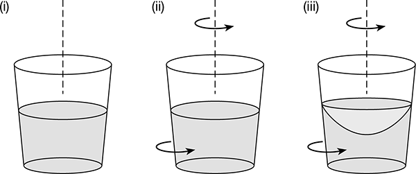

7.牛顿的“旋转水桶”实验。阶段（i）水桶和水静止；阶段（ii）水桶相对于水旋转；阶段（iii）水桶和水同步旋转。

7. Newton’s ‘rotating bucket’ experiment. Stage (i) bucket and water are at rest; stage (ii) bucket rotates relative to water; stage (iii) bucket and water rotate in tandem.

牛顿问道：是什么导致水面上升？显然，这与水的旋转有关。但旋转是一种运动，而对牛顿来说，物体的运动总是相对于其他事物而言的。因此，我们必须追问：水是相对于什么旋转的？显然不是相对于水桶，因为水桶和水是同步旋转的，因此它们处于相对静止状态。牛顿认为，水是*相对于绝对空间*旋转的，正是这种旋转导致水面向上弯曲。所以，绝对空间确实会对观测结果产生影响。

What is causing the surface of the water to rise, Newton asks? Clearly it is something to do with the water’s rotation. But rotation is a type of motion, and for Newton an object’s motion is always relative to something else. So we must ask: relative to what is the water rotating? Not relative to the bucket, obviously, for the bucket and water are rotating in tandem and are hence at relative rest. Newton argues that the water is rotating *relative to absolute space*, and that this is causing its surface to curve upwards. So absolute space does in fact have observational effects.

你或许认为牛顿的论证存在明显的漏洞。诚然，水相对于水桶没有旋转，但为什么就此得出结论说它一定相对于绝对空间在旋转呢？水相对于实验者、地球表面以及恒星都在旋转，那么这些因素中的任何一个都可能导致水面上升吗？然而，牛顿对此有一个简单的回应。想象一个宇宙，其中除了旋转的水桶之外什么都没有。在这样的宇宙中，我们无法通过水相对于其他物体的旋转来解释水面的弯曲，因为那里没有其他物体，而且水相对于水桶仍然是静止的。水唯一可能相对于其旋转的物体就是绝对空间。因此，我们必须相信绝对空间的存在，否则就无法解释水面为何会弯曲。

You may think there is an obvious gap in Newton’s argument. Granted the water is not rotating relative to the bucket, but why conclude that it must be rotating relative to absolute space? The water is rotating relative to the person doing the experiment, and relative to the earth’s surface, and relative to the fixed stars, so surely any of these might be causing its surface to rise? However Newton had a simple response to this move. Imagine a universe containing nothing except the rotating bucket. In such a universe, we cannot explain the water’s curved surface by appealing to the water’s rotation relative to other objects, for there are none, and as before the water is at rest relative to the bucket. Absolute space is the only thing left for the water to be rotating relative to. So we must believe in absolute space on pain of being unable to explain why the water’s surface curves.

实际上，牛顿的意思是，虽然物体相对于绝对空间的位置和速度永远无法被直接探测，但它相对于绝对空间的*加速度*却是可以探测的。因为当一个物体旋转时，即使旋转速率恒定，根据定义它也是加速的。这是因为在物理学中，加速度被定义为速度的变化率，而速度是指物体*在给定方向上的快慢。*由于旋转物体的运动方向不断变化，它们的速度并非恒定不变，因此它们就是在加速运动。水面的曲面就是所谓的“惯性效应”的一个例子——惯性效应是由加速运动产生的效应。另一个例子是飞机起飞时被推向座椅靠背的感觉。牛顿认为，惯性效应的唯一可能解释是，经历这些效应的物体相对于绝对空间的加速度。因为在一个只包含加速物体的宇宙中，绝对空间是唯一能够解释加速度的参照物。

In effect, Newton is saying that although an object’s position and velocity with respect to absolute space can never be detected, its *acceleration* with respect to absolute space is detectable. For when an object rotates then it is by definition accelerating, even if the rate of rotation is constant. This is because in physics, acceleration is defined as the rate of change of velocity, and velocity is speed *in a given direction.* Since rotating objects are constantly changing their direction of motion, their velocity is not constant, hence they are accelerating. The water’s curved surface is just one example of what are called ‘inertial effects’—effects produced by accelerated motion. Another example is the feeling of being pushed to the back of your seat when an aeroplane takes off. The only possible explanation of inertial effects, Newton believed, is the acceleration of the object experiencing those effects with respect to absolute space. For in a universe containing only the accelerating object, absolute space is the only thing that the acceleration could be relative to.

牛顿的论证很有力，但并非结论性的。因为，如果旋转水桶实验是在一个没有任何其他物质的宇宙中进行的，牛顿又如何知道水面*会*向上弯曲呢？牛顿只是假设，我们在现实世界中观察到的惯性效应，在一个没有任何物质的世界中仍然会保持不变。

Newton’s argument is powerful but not conclusive. For how does Newton know that the water’s surface *would* curve upwards, if the rotating bucket experiment were done in a universe containing no other material objects? Newton simply assumes that the inertial effects we find in this world would remain the same in a world bereft of any other matter.

这显然是一个相当大的假设，许多人质疑牛顿是否有资格做出这样的假设。因此，牛顿的论证并不能证明绝对空间的存在。相反，它向莱布尼茨理论的捍卫者提出了挑战，要求其对惯性效应提供另一种解释。

This is obviously quite a substantial assumption, and many people have questioned Newton’s entitlement to it. So Newton’s argument does not prove the existence of absolute space. Rather, it lays down a challenge to the defender of Leibniz to provide an alternative explanation of inertial effects.

莱布尼茨还面临着如何在不引入绝对空间的情况下解释绝对运动和相对运动区别的挑战。针对这个问题，莱布尼茨写道，当物体运动的直接原因是物体自身时，该物体就处于真运动或绝对运动状态。回想一下滑翔机和地球上的观察者，它们都相对于对方运动。为了确定谁“真正”在运动，莱布尼茨认为我们需要判断运动的直接原因（即相对运动）是在滑翔机上还是在观察者身上。这种区分绝对运动和相对运动的方法完全避免了提及绝对空间，但并不十分清晰。莱布尼茨从未真正解释过“运动的直接原因”在物体内部究竟*意味着*什么。但他或许意在反驳牛顿的假设，即物体的运动，无论是相对运动还是绝对运动，都只能反映物体与其他事物之间的关系。

Leibniz also faces the challenge of explaining the difference between absolute and relative motion without invoking absolute space. On this problem, Leibniz wrote that a body is in true or absolute motion ‘when the immediate cause of the change is in the body itself’. Recall the case of the hang-glider and the observer on earth, both in motion relative to the other. To determine who is ‘really’ moving, Leibniz would say that we need to decide whether the immediate cause of the change (i.e. the relative motion) is in the hang-glider or the observer. This suggestion for how to distinguish absolute from relative motion avoids all reference to absolute space, but it is not very clear. Leibniz never properly explains what it *means* for the ‘immediate cause of the change’ to be in an object. But it may be that he intended to reject Newton’s assumption that an object’s motion, whether relative or absolute, can only be a fact about the object’s relations to something else.

绝对空间与相对空间之争最引人入胜之处在于它始终挥之不去。牛顿的空间理论与他的物理学密不可分，而莱布尼茨的观点则是对牛顿理论的直接回应。因此，人们或许会认为，自17世纪以来物理学的进步应该已经解决了这个问题。然而事实并非如此。尽管人们一度普遍认为爱因斯坦的相对论已经使莱布尼茨的观点胜出，但近年来这种观点受到了越来越多的质疑。在牛顿与莱布尼茨最初的论战300多年后，这场争论仍在继续。

One of the intriguing things about the absolute/relational controversy is that it refuses to go away. Newton’s account of space was intimately bound up with his physics, and Leibniz’s views were a direct reaction to Newton’s. So one might think that advances in physics since the 17th century would have resolved the issue. But this has not happened. Although it was once widely held that Einstein’s theory of relativity had decided the issue in favour of Leibniz, this view has increasingly come under attack in recent years. More than 300 years after the original Newton/Leibniz exchange, the debate continues.

# 什么是生物物种？

# What are biological species?

科学家常常希望将他们研究的对象归类为不同的种类或类型。地质学家将岩石分为火成岩、根据形成方式的不同，元素可分为沉积岩或变质岩。化学家根据元素的物理和化学性质，将其分为金属、类金属和非金属。分类的主要功能是传递信息。如果化学家告诉你某种物质是金属，这就能让你对它的性质有大致的了解。分类引发了一些有趣的哲学问题。这些问题主要源于这样一个事实：一组给定的物体原则上可以用多种不同的方式进行分类。那么，我们应该如何选择呢？是否存在一种“正确”的分类方法？或者说，所有的分类方案最终都是任意的？在*生物*分类学的背景下，这些问题显得尤为重要，而生物分类学正是我们本文的关注点。

Scientists often wish to classify the objects they are studying into general kinds or types. Geologists classify rocks as igneous, sedimentary, or metamorphic, depending on how they were formed. Chemists classify elements as metals, metalloids, or non-metals, depending on their physical and chemical attributes. The main function of classification is to convey information. If a chemist tells you that something is a metal, this tells you a lot about its likely behaviour. Classification raises some interesting philosophical issues. Mostly, these stem from the fact that a given set of objects can in principle be classified in many different ways. So how should we choose between them? Is there a ‘correct’ way to classify, or are all classification schemes ultimately arbitrary? These questions take on a particular urgency in the context of *biological* classification or taxonomy, which will be our concern here.

生物分类的基本单位是物种。在传统分类学中，每个生物首先被归入一个物种，物种名称由拉丁文两部分组成，称为二项式。因此，你属于*智人（Homo sapiens）*，你的宠物猫属于猫*（Felis catus）*，你食品储藏室里的老鼠属于小家鼠（*Mus musculus*）。然后，物种按照层级顺序排列到“更高级别的分类单元”——属、科、目、纲、门和界。因此，智人（ *Homo sapiens）*属于人属（Homo），人属又属于人科（Hominid）、灵长目（Primate）、哺乳纲（Mammalia）、脊索动物门（Chordate）和动物界（Animal）。这种分类系统被称为*林奈系统*，以其发明者——18世纪瑞典博物学家卡尔·林奈（Carl Linnaeus，1707-1778）的名字命名，至今仍被广泛使用。

The basic unit of biological classification is the species. In traditional taxonomy each organism is first assigned to a species, denoted by a Latin name with two parts called a binomial. Thus you belong to *Homo sapiens*, your pet cat to *Felis catus*, and the mouse in your larder to *Mus musculus*. Species are then arranged into ‘higher taxa’—genus, family, order, class, phylum, and kingdom—in a hierarchical fashion. Thus *Homo sapiens* is in the Homo genus, which is in the Hominid family, the Primate order, the Mammalian class, the Chordate phylum, and the Animal kingdom. This system of classification is called the *Linnean system*, named after the 18th-century Swedish naturalist Carl Linnaeus (1707–78) who invented it, and is still widely used today.

本文将重点讨论分类学家任务的第一阶段，即如何将生物体归类到物种。这远比看起来复杂，主要是因为生物学家对于物种的真正定义以及物种鉴定的标准尚未达成共识。事实上，现代生物学中充斥着各种相互竞争的物种定义，或者说“物种概念”。这种缺乏共识的情况有时被称为“物种问题”。

Our focus here will be on the first stage of the taxonomist’s task, namely how to assign organisms to species. This is less straightforward than it may seem, primarily because biologists do not agree on what a species actually is, nor therefore on what criteria should be used for identifying species. Indeed competing definitions of a biological species, or ‘species concepts’ as these definitions are known, abound in modern biology. This lack of consensus is sometimes called ‘the species problem’.

你或许会惊讶地发现，物种问题确实存在。从普通人的角度来看，将生物归类为物种似乎并没有什么问题。毕竟，即使是粗略的观察也能清楚地看出，生物体并非千篇一律。有些生物体型庞大，有些则非常微小；有些会移动，有些则不会；有些能活数年，有些则只能存活几个小时。同样显而易见的是，这种多样性并非连续的，而是呈聚集分布的。生物体似乎可以归入若干离散的类型或种类，其中许多类型甚至连小孩子都能识别。一个三岁的孩子可以自信地判断公园里的两只动物都是狗，即使它们的品种不同；而生物学家也会证实孩子的判断是正确的——这些动物确实属于同一物种，即*家犬（Canis familiaris*）。因此，人们自然会认为生物体之间存在客观的界限，而生物学家的职责就是发现这些界限。在这种观点看来，物种的边界存在于世界之中，等待着人们去发现，而不是由生物学家强加于世界的。大多数非生物学家似乎都毫不质疑地接受这种观点。

You may be surprised to hear that there is a species problem. From a layperson’s perspective, there seems nothing very problematic about assigning organisms to species. After all, it is clear from even casual observation that living organisms are not all alike. Some are enormous while others are tiny; some move while others don’t; some live for years and others for just a few hours. It is equally clear that this diversity is not continuous but clustered. Organisms appear to fall into a discrete number of types or kinds, many of which can be recognized by young children. A 3-year-old can confidently judge that two animals in the park are both dogs, even if they are of different breeds; and a biologist will confirm that the child is correct—the animals do indeed belong to the same species, namely *Canis familiaris*. Thus it is natural to think that there are objective divisions between living organisms that it is the job of the biologist to discover. On this view, species boundaries are ‘out there’ in the world awaiting discovery, rather than being imposed on the world by biologists. Most non-biologists appear to accept this view without question.

这种常识性的观点与“自然种类”的哲学学说不谋而合，该学说的各种变体自亚里士多德以来就广为流传。这一学说认为，存在一些方法可以将物体归类为自然种类，这些种类之所以自然，是因为它们对应于世界上真实存在的划分，而不是反映人类的兴趣。化学元素和化合物就是典型的自然种类。例如，考虑宇宙中所有纯金的样本。这些样本都属于“金”这一种类，因为它们在一个根本方面是相同的：构成它们的原子原子序数均为79。相比之下，黄铁矿（愚人金）的样本虽然在某些方面与金相似，但它并不属于这一种类，因为它是由不同种类的原子（铁和硫）组成的化合物。信奉科学实在论的哲学家通常认为，任何科学的部分任务就是在其领域内发现自然种类。

This commonsense viewpoint dovetails with the philosophical doctrine of ‘natural kinds’, variants of which have been popular since Aristotle. This doctrine holds that there are ways of grouping objects into kinds that are natural in the sense of corresponding to divisions that really exist in the world, rather than reflecting human interests. Chemical elements and compounds are paradigm natural kinds. Consider for example all the samples of pure gold in the universe. These samples are of the kind ‘gold’ because they are alike in a fundamental respect: their constituent atoms have atomic number 79. By contrast, a sample of fool’s gold (iron pyrite) does not belong in that kind, despite being similar to gold in some respects, for it is a compound formed by atoms of a different sort (iron and sulphur). Philosophers who embrace scientific realism often argue that part of the job of any science is to discover the natural kinds in its domain.

物种是生物学自然分类的观点固然吸引人，但也面临诸多挑战。其中之一是，物种的界定可能存在一定的任意性。为了理解这一点，我们不妨看看生物学家如何将物种细分为品种、变种和亚种等类别。例如，金雕（*Aquila chrysaetos）*通常被分为六个亚种，包括欧洲金雕、美洲金雕和日本金雕。引入亚种分类的动机在于，某些种群之间存在明显的差异，但差异又不足以被视为不同的物种。然而，我们该如何划定清晰的界限呢？达尔文在*《物种起源》*中对此进行了有趣的探讨，他认为物种、亚种和变种之间并不存在明确的界限。他总结道：“可以看出，我把‘物种’这个术语看作是为了方便而随意赋予一组彼此非常相似的个体的术语，它与‘变种’这个术语本质上并没有区别，‘变种’指的是不太明显且变化更大的形态。”

The idea that species are the natural kinds of biology is an attractive one, but faces a number of challenges. One is that there may be an element of arbitrariness in what counts as a species. To see why, note that biologists often subdivide species into groupings such as breeds, varieties, and sub-species. For example the golden eagle *Aquila chrysaetos* is usually divided into six sub-species, which include the European, American, and Japanese golden eagle. The motivation for introducing sub-specific groupings is that some populations are recognizably different from each other, but not so different as to count as separate species. But how do we draw a sharp line? Darwin offers an interesting discussion of this point in *The Origin of Species*, arguing that no clear demarcation exists between species, sub-species, and varieties. He concluded: ‘it will be seen that I look at the term species as one arbitrarily given, for the sake of convenience, to a set of individuals closely resembling each other, and that it does not essentially differ from the term variety, which is given to less distinct and more fluctuating forms.’

达尔文认为一组个体是否构成一个物种是任意的，这令人惊讶；这显然与物种作为自然种类的概念不符。但达尔文的观点正确吗？在20世纪，许多进化生物学家确信，物种实际上是自然界中的真实单元，而非任意的分组，理由是它们之间存在*生殖隔离*。这意味着同一物种内的个体可以相互交配，但不能与其他物种的个体交配。德国生物学家恩斯特·迈尔倡导用生殖隔离来定义生物物种，这一概念被称为“生物物种概念”（BSC）。BSC的支持者驳斥了达尔文关于变种/物种区分是任意的论点。在他们看来，欧洲金雕和美洲金雕是变种，而非不同的物种，因为它们原则上可以交配并产生可育后代（即使这种情况很少发生）。相比之下，斑雕和金雕是不同的物种，因为它们的成员不能交配。

Darwin’s suggestion that whether a set of individuals counts as a species is arbitrary is surprising; certainly it does not fit with the idea of species as natural kinds. But is Darwin right? In the 20th century, many evolutionary biologists became convinced that species are in fact real units in nature, not arbitrary groupings, on the grounds that they are *reproductively isolated*. This means that the organisms within a species can interbreed with each other but not with those of other species. Defining biological species in terms of reproductive isolation was championed by the German biologist Ernst Mayr, and became known as the ‘biological species concept’ (BSC). Proponents of the BSC reject Darwin’s argument that the variety/species distinction is arbitrary. On their view, the European and American golden eagles are varieties, not separate species, since they can in principle interbreed and produce viable offspring (even if they do so rarely). By contrast, the spotted eagle and the golden eagle are separate species, since their members cannot interbreed.

生物物种隔离理论（BSC）在现代生物学中被广泛应用，但它也存在局限性。该理论仅适用于有性生殖生物；然而，许多生物进行无性生殖，包括大多数单细胞生物、一些植物和真菌以及少数动物。因此，BSC充其量只能部分解决物种问题。此外，生殖隔离并非总是绝对的。生活在相邻区域的近缘物种常常在其分布范围交汇处形成“杂交带”；在这些区域，会发生一定程度的杂交，至少在某些情况下会产生可育后代，但两个物种仍然保持各自的独立性。杂交带通常出现在一个物种分裂成两个物种的过程中。尤其是在植物中，属于明显不同物种的个体之间的杂交现象十分普遍。

The BSC is widely used in contemporary biology, but it has limitations. It only applies to sexually reproducing organisms; however, many living organisms reproduce asexually, including most single-celled organisms, some plants and fungi, and a few animals. So the BSC is at best a partial solution to the species problem. Moreover, reproductive isolation is not always a hard and fast matter. Closely related species who live in adjacent locations often have ‘hybrid zones’ where their ranges meet; in these zones, a limited amount of hybridization takes place, in which fertile offspring are produced at least some of the time, but the two species retain their distinct identities. Hybrid zones often arise when one species is in the process of splitting into two. Among plants, in particular, hybridization between organisms that belong to clearly distinct species is quite common.

对于生物安全中心（BSC）而言，更棘手的问题是环状物种现象。当一个物种由若干个在地理上呈环状分布的局部种群组成时，就会出现这种情况；每个种群都可以与其相邻的种群杂交，但位于环状分布链末端的种群则不能。例如，假设种群 A 可以与 B 杂交，B 可以与 C 杂交，C 可以与 D 杂交，D 可以与 E 杂交，但 A 和 E 不能杂交（见图8）。环状物种对生物安全中心来说构成了一种悖论。为了理解这一点，不妨问问自己 A 和 E 是否属于同一物种。由于它们不能杂交，答案应该是“否”。然而，根据杂交标准，A 和 B 是同种的，B 和 C、C 和 D 以及 D 和 E 也是如此，那么 A 和 E 肯定*也是*同种的吧？在生物安全中心，对于这种情况，我们很难给出明确的解释。因此，达尔文坚持认为，物种的认定存在任意性，而对生殖隔离的关注并不能完全消除这种任意性。

Still more problematic for the BSC is the phenomenon of ring species. This occurs when a species comprises a number of local populations arranged geographically in a ring; each population can interbreed with an immediate neighbour, but the populations at the end of the chain cannot. For example, suppose population A can interbreed with B, B with C, C with D, D with E, but A and E cannot interbreed (see Figure 8). Ring species constitute a kind of paradox for the BSC. To see why, ask yourself whether A and E belong to the same species or not. Since they cannot interbreed, the answer should be ‘no’. However A and B are con-specific by the interbreeding criterion, as are B and C, C and D, and D and E, so surely A and E *must* be con-specific? It is quite unclear what to say about this situation, on the BSC. So Darwin’s insistence that there is an element of arbitrariness in what gets counted as a species is not entirely defused by the focus on reproductive isolation.

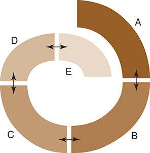

8.环状物种。双箭头表示杂交。

8. Ring species. A double-headed arrow indicates interbreeding.

物种问题的根本原因在于进化本身。现代生物学遵循达尔文的理论告诉我们，所有生物都起源于共同的祖先。然而，传统的林奈分类学却源于神创论盛行的时代。主流世界观。在创造论的观点中，上帝分别创造了每个物种，因此人们自然会认为所有生物都可以被明确地归类到不同的物种。但在进化论的观点中，这种预期是不成立的。因为进化是一个渐进的过程——一个祖先物种演化成一个子物种的过程通常需要数千年。它常常涉及一个物种逐渐分裂成两个，最终两个子物种之间的生殖联系断裂。因此，过渡形态以及物种地位不明的种群的存在是必然的。此外，也没有理由认为单一的物种定义能够适用于所有生物，从细菌到多细胞动物。

The underlying source of the species problem is evolution itself. Modern biology teaches us, following Darwin, that all living organisms derive from a common ancestor. However traditional Linnean taxonomy derives from a time when creationism was the dominant worldview. On a creationist view, in which God created each species separately, it is natural to expect that all organisms can be assigned to species unambiguously. But on an evolutionary view there is no reason to expect this. For evolutionary change is gradual—the process by which an ancestral species gives rise to a daughter species typically takes many thousands of years. Often it involves one species gradually splitting into two, with reproductive links between the two daughter species eventually being severed. So transitional forms, and populations whose status as species is unclear, are only to be expected. Moreover, there is no reason to expect that a single species definition will work for all organisms, from bacteria to multi-celled animals.

进化论也告诉我们，生物体之间的*变异*很可能普遍存在。因为变异是自然选择的驱动力：如果一个物种内的生物体没有变异，自然选择就无法发挥作用。这意义重大，因为它动摇了人们的常识性观念，即生物物种的成员必须都具备某些本质特征，例如某些遗传属性，才能将它们与其他物种区分开来。这种观念是物种“自然类”观的一部分，也是许多非生物学家似乎认同的观点。然而，经验表明，生物体之间存在广泛的遗传变异。典型物种内部的个体差异有时甚至超过近缘物种之间的遗传变异。这并非否认生物学家通常可以通过DNA测序来确定生物体所属的物种。然而，这并非总是可行，也并不意味着物种归属是由固定的“遗传本质”决定的。

Evolution also teaches us that *variation* among organisms is likely to be pervasive. For variation is the engine that drives natural selection: if the organisms in a species do not vary then natural selection cannot operate. The significance of this is that it undermines the commonsense idea that the members of a biological species must all possess some essential feature, e.g. some genetic property, which sets them apart from non-members. This idea is part of the ‘natural kind’ view of species, and is something that many non-biologists appear to believe. Empirically, however, there is extensive genetic variation among the individuals within a typical species, which sometimes exceeds the genetic variation between closely related species. This is not to deny that biologists can often tell what species an organism belongs to by sequencing its DNA. However this is not always possible, and it does not show that membership of a species is determined by a fixed ‘genetic essence’.

因此，进化极大地增加了分类学的复杂性。然而，分类学工作必须继续进行，因为将生物体划分为物种实际上是不可或缺的。例如，如果一位鸟类学家遇到一只不寻常的鸟，他们首先想知道的就是它属于哪个物种，因为这能提供关于其特征、行为和生态的重要信息。英国生物学家约翰·梅纳德·史密斯曾精辟地描述过这种情况，他写道：“任何试图将所有生物体，无论古今，划分成界限分明、彼此之间不存在中间状态的类群的尝试，都注定会失败。分类学家面临着一项任务在实践上的必要性和理论上的不可能性之间的矛盾。” 因此，在实践中，生物学家仍然像对待界限分明的类群一样对待物种，尽管他们也知道这只是对现实的一种近似。

Evolution therefore complicates the taxonomic enterprise considerably. However the enterprise must go on, for dividing organisms into species is practically indispensable. If an ornithologist comes across an unusual bird, for example, the first thing they will want to know is what species it is from, as this provides valuable information about its traits, behaviour, and ecology. The situation was eloquently described by the English biologist John Maynard Smith, who wrote: ‘any attempt to divide all living organisms, past and present, into sharply defined groups between which no intermediates exist, is foredoomed to failure. The taxonomist is faced with a contradiction between the practical necessity and the theoretical impossibility of his task.’ So in practice biologists continue to treat species as if they were sharply defined kinds, in the knowledge that this is only an approximation to reality.

自20世纪60年代末以来，进化生物学日益倾向于认为分类应该与进化“一致”。这正是由德国昆虫学家威利·亨尼格创立的“系统发育系统学”运动的*核心思想。其核心理念是，只有**单系*群才被认为是真正的生物类群，这意味着它们包含且仅包含某个共同祖先的所有后代。许多传统的分类群，例如*爬行纲*（爬行动物），已被证明并非单系群——在这种情况下，因为所有爬行动物的祖先也演化出了鸟类（见图9）。因此，系统发育分类的支持者坚持认为，*爬行纲*并非真正的分类单元，在正确的分类体系中不应占有一席之地。系统学主要关注如何界定更高级别的分类单元，而非物种。然而，单系性标准可以应用于单个物种，由此产生所谓的“系统发育物种概念”；实际上，这一概念旨在精确地阐述一个直观的想法，即同一物种内的个体之间的亲缘关系应该比与其他物种的成员之间的亲缘关系更近。

From the late 1960s onwards, evolutionary biology has increasingly converged on the idea that classification should be done in a way that is ‘consistent’ with evolution. This was the *leitmotif* of the movement known as ‘phylogenetic systematics’, founded by the German entomologist Willi Hennig. The key idea was to recognize as genuine only those biological groupings that are *monophyletic*, which means that they contain all and only the descendants of some common ancestor. Many traditional taxonomic groupings, e.g. the class *Reptilia* (the reptiles), have turned out not to be monophyletic—in this case, because the ancestor of all the reptiles also gave rise to the birds (see Figure 9). So proponents of phylogenetic classification insist that *Reptilia* is not a genuine taxon, and has no place in a correct taxonomy. Phylogenetic systematics is mainly concerned with how to delimit higher taxa, rather than species. However the monophyly criterion can be applied to individual species, yielding what is known as the ‘phylogenetic species concept’; in effect, this concept is an attempt to formulate precisely the intuitive idea that the organisms within a species should be more closely related to each another than to the members of other species.

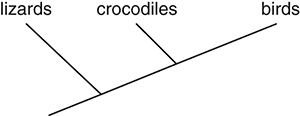

9.蜥蜴、鳄鱼和鸟类之间的系统发育关系。

9. Phylogenetic relationship between lizards, crocodiles, and birds.

从哲学角度来看，系统发育方法的意义在于，它表明两个生物体之所以属于同一类群——物种或更高级别的分类单元——是因为它们拥有共同的祖先，而非它们内在的相似性。一个思想实验可以帮助我们更好地理解这一点。假设科学家在火星上发现了一种生物体，它并非源自地球生物物质，但却与常见的家蝇完全无法区分。（当然，这种情况发生的概率极低，但从逻辑上讲是可以设想的。）这个火星样本看起来像家蝇，可以与地球上的家蝇杂交，并且任何基因检测都无法将其与真正的家蝇区分开来。那么，它算是家蝇吗？如果物种是自然界的种类，那么答案很可能是肯定的。但从系统发育的角度来看，答案是否定的。要被认定为家蝇（*Musca domestica*）物种，一个生物体需要具备相应的祖先模式，而与其内在特征无关。

From a philosophical viewpoint, the significance of the phylogenetic approach is its implication that two organisms belong to the same group—species or higher taxon—because of their shared ancestry, rather than their intrinsic similarity. A thought experiment can help flesh this out. Suppose that scientists find an organism on Mars that is not derived from earthly biological matter, but nonetheless is completely indistinguishable from a common housefly. (This is incredibly unlikely, of course, but it is logically conceivable.) The Martian specimen looks like a housefly, can interbreed with houseflies back on earth, and cannot be told apart from true houseflies by any genetic tests. Is it a housefly? If species were natural kinds, the answer would presumably be yes. But on a phylogenetic view, the answer is no. To be of the housefly species (*Musca domestica*), an organism needs to have the appropriate pattern of ancestry, irrespective of what intrinsic features it has.

这与生物学家迈克尔·吉塞林和哲学家大卫·赫尔在20世纪70年代提出的一个有趣的观点不谋而合。他们认为，生物物种根本不应该被视为一种类型或类别（这是传统的假设），而应该被视为一个独立的个体。物种如同一个在时空维度上延伸的复杂个体。如同单个生物体，物种诞生于特定的时空，拥有有限的寿命，最终走向灭绝。与之相反，真正的“类”在时空上是不受限制的。以黄金为例。宇宙中任何物质，无论其来源如何，只要原子序数为79，都可被视为黄金。因此，理论上，宇宙中所有的黄金都可以被摧毁，多年以后又可以合成新的黄金。但吉塞林和赫尔认为，物种并非如此。一旦一个物种灭绝，从逻辑上讲，它就永远不可能再次出现，就像你我死后无法复活一样。

This tallies with an intriguing suggestion made by the biologist Michael Ghiselin and the philosopher David Hull in the 1970s. They argued that a biological species should not be regarded as a kind or type at all, which is the traditional assumption, but rather as a complex individual extended in space and time. Like an individual organism, a species comes into existence at a particular place and time, has a finite lifespan, and then goes extinct. By contrast, a genuine kind is spatiotemporally unrestricted. Consider gold. A piece of matter anywhere in the universe counts as gold, irrespective of its origin, so long as it has atomic number 79. So in principle, all the gold in the universe could be destroyed and then years later some more could be synthesized. But species are not like this, Ghiselin and Hull argued. Once a species goes extinct it can never come back into existence as a matter of logic, any more than you or I can survive our deaths.

物种是独立个体的观点乍听之下或许有些奇怪，但仔细思考后便会发现其中的道理。诚然，物种与“普通”个体不同，因为它们的组成部分，即它们所包含的生物体，并非彼此相连。然而，这种区别相当表面化。蚁群中的昆虫也并非彼此相连，但我们仍然乐于将蚁群视为一个独立的个体。将物种视为独立个体具有显著的优势。首先，它与系统发育学的原则高度契合。其次，它有助于调和以下两点：一方面，人们普遍认为物种是自然界中“真实”的单元，而非任意的分类；另一方面，种内遗传变异普遍存在，物种并不具有“遗传本质”。如果我们把物种视为复杂的个体，这些事实便能得到合理的解释；但如果我们把它们视为自然种类，这些事实就显得难以理解了。

The idea that species are individuals sounds strange at first but makes sense on reflection. Certainly, species are unlike ‘ordinary’ individuals in that their constituent parts, i.e. the organisms they contain, are not joined together. However this difference is fairly superficial. The insects in an ant colony are not joined together either, but we are happy to regard the colony as an individual thing. Treating species as individuals has distinct advantages. One is that it fits well with the principles of phylogenetic systematics. Another is that it helps reconcile the widespread intuition that species are ‘real’ units in nature, not arbitrary groupings, with the fact that intra-specific genetic variation is widespread and that species do not have ‘genetic essences’. These facts make good sense if we view species as complex individuals, but make much less sense if we regard them as natural kinds.

# 思维是模块化的吗？

# Is the mind modular?

人类能够完成各种各样的认知任务，而且通常无需太多意识努力，这是一个令人惊叹的事实。我们所说的“认知任务”不仅指解填字游戏之类的事情，还包括安全过马路、接球、理解他人说话、识别他人面孔等日常任务。这些任务对我们来说如此熟悉，以至于我们很容易习以为常；然而，我们完成这些任务的能力却远非我们想象的那般简单。完成这些任务确实令人惊叹。尽管造价不菲，但没有任何机器人能够像普通人那样出色地完成大多数此类任务。我们的大脑以某种方式使我们能够以最小的努力完成复杂的认知任务。解释这种现象是认知心理学这一学科的重要组成部分。

It is a striking fact that humans are able to perform a diverse array of cognitive tasks, often with fairly little conscious effort. By ‘cognitive tasks’ we do not just mean things like solving crossword puzzles, but also everyday tasks like crossing the road safely, catching a ball, understanding what other people say, recognizing other people’s faces, and more. Such tasks are so familiar to us that they are easily taken for granted; however our ability to perform them is really quite remarkable. No robot comes close to being able to perform most of these tasks as well as an average human, despite considerable expense. Somehow or other, our brains enable us to perform complex cognitive tasks with minimal effort. Explaining how this could be is an important part of the discipline known as cognitive psychology.

我们关注的是认知心理学家之间关于人类心智结构的持续争论。一种观点认为，人类心智是一个“通用问题解决者”。这意味着心智包含一套通用的问题解决技能，或称“通用智能”，并将其应用于数量无限多的不同任务。因此，无论一个人是在数弹珠、决定去哪家餐厅吃饭，还是学习一门外语，所使用的都是同一套认知能力——这些任务代表了人类通用智能的不同应用。另一种观点则认为，人类心智包含许多专门的子系统或模块，每个子系统或模块都旨在执行特定的任务，而不能执行其他任何任务。这被称为*心智模块化*假说。

Our focus is an ongoing debate among cognitive psychologists concerning the architecture of the human mind. According to one view, the human mind is a ‘general-purpose problem solver’. This means that the mind contains a set of general problem-solving skills, or ‘general intelligence’, which it applies to an indefinitely large number of different tasks. So one and the same set of cognitive capacities are employed, whether a person is trying to count marbles, decide which restaurant to eat in, or learn a foreign language—these tasks represent different applications of the person’s general intelligence. According to a rival view, the human mind contains a number of specialized sub-systems or modules, each of which is designed for performing a specific task and cannot do anything else. This is known as the *modularity of mind* hypothesis.

语言学专家诺姆·乔姆斯基在20世纪60年代关于语言习得的研究中，就体现了模块化的一个例子。乔姆斯基坚持认为，儿童并非通过偷听成人对话，然后运用其“一般智力”来推断所讲语言的规则而习得语言。他认为，这是不可能的，因为儿童接触到的语言数据非常有限，而且因人而异；然而，所有儿童习得语言的年龄却大致相同。乔姆斯基提出，每个儿童的大脑中都存在一个被称为“语言习得装置”的独特模块。该装置自动运行，其唯一功能是帮助儿童习得语言。它通过编码所有人类语言都遵循的“普遍语法”原则来实现这一点，使儿童在适当的提示下能够学习任何语言的语法。乔姆斯基还提出了一个……一系列令人印象深刻的证据支持语言习得是一种模块化能力的说法——例如，即使是“一般智力”较低的人通常也能学会说一口流利的英语。

One example of modularity comes from the work of the linguist Noam Chomsky on language acquisition in the 1960s. Chomsky insisted that a child does not learn language by overhearing adult conversation and then using their ‘general intelligence’ to figure out the rules of the language being spoken. This is impossible, he argued, for the linguistic data that children are exposed to are too limited, and vary greatly from child to child; yet all children acquire language by the same age. Chomsky argued that there is a distinct module called the ‘language acquisition device’ in every child’s brain. The device operates automatically, and its sole function is to enable the child to acquire language. It does this by encoding the principles of ‘universal grammar’ that all human languages obey, enabling the child to learn the grammar of any language given appropriate prompting. Chomsky provided an array of impressive evidence for the claim that language acquisition is a modular capacity—such as the fact that even those with low ‘general intelligence’ can usually learn to speak perfectly well.

支持模块化假说的最有力证据之一来自对脑损伤患者的研究，即所谓的“缺陷研究”。如果人类大脑是一个通用问题解决系统，我们预期大脑损伤会对所有认知能力产生大致相同的影响。但事实并非如此。相反，脑损伤通常会损害某些认知能力，而对其他能力则不受影响。例如，大脑中被称为韦尼克区的损伤会导致患者无法理解语言，但他们仍然能够流畅地表达语法正确的句子。这有力地表明，句子生成和理解是两个独立的模块——因为这可以解释为什么理解能力的丧失不会导致句子生成能力的丧失。其他脑损伤患者会丧失长期记忆（失忆症），但他们的短期记忆以及说话和理解能力却不受影响。这似乎再次支持了模块化假说，并反驳了大脑是一个通用问题解决系统的观点。

Some of the most compelling evidence for the modularity hypothesis comes from studies of patients with brain damage, known as ‘deficit studies’. If the human mind is a general-purpose problem solver, we would expect damage to the brain to affect all cognitive capacities more or less equally. But this is not what we find. On the contrary, brain damage often impairs some cognitive capacities but leaves others untouched. For example, damage to a part of the brain known as Wernicke’s area leaves patients unable to understand speech, though they are still able to produce fluent, grammatical sentences. This strongly suggests that there are separate modules for sentence production and comprehension—for this would explain why loss of the latter capacity does not entail loss of the former. Other brain-damaged patients lose their long-term memory (amnesia), but their short-term memory and ability to speak and understand are unimpaired. Again, this seems to speak in favour of modularity and against the view of the mind as a general-purpose problem solver.

尽管这类神经心理学证据令人信服，但它们并不能彻底解决模块化问题。此类证据相对稀少——我们显然不能随意损伤人的大脑，仅仅为了观察其认知能力会受到怎样的影响。此外，正如科学界常见的现象，对于如何解读这些数据也存在分歧。一些人认为，在脑损伤患者中观察到的认知障碍模式并不意味着大脑具有模块化。他们认为，即使大脑是一个通用问题解决系统，即非模块化的，不同的认知能力仍然可能受到脑损伤的不同程度的影响。因此，我们不能简单地从缺陷研究中推断出大脑的结构；充其量，后者只能为前者提供不可靠的证据。

Though compelling, neuropsychological evidence of this sort does not settle the modularity issue decisively. Such evidence is relatively sparse—we obviously cannot damage people’s brains at will just to see how their cognitive capacities are affected. In addition, there are disagreements about how the data should be interpreted, as is usual in science. Some argue that the observed pattern of cognitive impairment in brain-damaged patients does not imply modularity. Even if the mind were a general-purpose problem solver, i.e. non-modular, it is still possible that distinct cognitive capacities might be differentially affected by brain damage, they argue. So we cannot simply read off the architecture of the mind from deficit studies; at best, the latter provide fallible evidence for the former.

近年来人们对模块化的浓厚兴趣很大程度上归功于美国哲学家兼心理学家杰里·福多（Jerry Fodor）的研究。在1983年出版的*《心智的模块化》（The Modularity of Mind）*一书中，福多对模块的概念提出了新颖的解释，并就哪些认知能力是模块化的、哪些不是提出了一些有趣的观点。福多认为，心理模块具有一些显著特征，其中三个尤为重要：（i）它们具有*领域特异性*；（ii）它们的运作是*强制性的*；（iii）它们*在信息上是封装的*。非模块化系统则缺乏这些特征。福多进一步指出，心智部分地是模块化的，但并非完全如此：我们利用专门的模块来解决一些认知任务，而利用我们的一般智能来解决另一些任务。

Much of the recent interest in modularity is due to the work of Jerry Fodor, an American philosopher and psychologist. In a 1983 book entitled *The Modularity of Mind* Fodor offered a novel account of what a module is, and some interesting ideas about which cognitive capacities are modular and which not. Fodor argued that mental modules have a number of distinguishing features, of which three are particularly important: (i) they are *domain-specific*, (ii) their operation is *mandatory*, and (iii) they are *informationally encapsulated*. Non-modular systems lack these features. Fodor then argued that the mind is partly though not wholly modular: we solve some cognitive tasks using specialized modules, others using our general intelligence.

认知系统具有领域特异性，意味着它具有专门性：它执行一组有限的、精确界定的任务。乔姆斯基提出的语言习得机制就是一个例子。该机制的唯一功能是帮助儿童学习语言——它不会帮助儿童学习下棋、计数或其他任何技能。因此，该机制会忽略非语言输入。认知系统具有强制性，意味着我们无法选择是否启用它。语言感知就是一个例子。如果你听到一句用你熟悉的语言说出的句子，你必然会将其听作一个完整的句子。如果有人要求你把这句话听作“纯粹的噪音”，无论你多么努力，你都无法做到。福多指出，并非所有认知过程都具有这种强制性。清晰思考就不是。如果有人让你想想你一生中最可怕的时刻，或者想想如果你中了彩票你会做什么，你显然可以按照他们的指示去做。因此，思维和语言感知在这方面截然不同。

To say that a cognitive system is domain-specific is to say that it is specialized: it performs a limited, precisely circumscribed set of tasks. Chomsky’s postulated language acquisition device is an example. The sole function of this device is to enable the child to learn language—it doesn’t help the child learn to play chess, or to count, or anything else. So the device ignores non-linguistic inputs. To say that a cognitive system is mandatory is to say that we cannot choose whether to put it into operation. The perception of language is an example. If you hear a sentence uttered in a language you know, you cannot help but hear it as the utterance of a sentence. If someone asked you to hear the sentence as ‘pure noise’ you couldn’t obey them however hard you tried. Fodor points out that not all cognitive processes are mandatory in this way. Thinking clearly is not. If someone asked you to think of the scariest moment in your life, or of what you would do if you won the lottery, you clearly could obey their instructions. So thinking and language perception are quite different in this regard.

那么信息封装呢？这个概念最好用一个例子来说明。请看图 10中的两条平行线。对大多数人来说，上面的线看起来比下面的线略长。但实际上，这是一种视觉错觉，称为缪勒-莱尔错觉。这两条线的长度实际上是相等的。

What about informational encapsulation? This notion is best illustrated by an example. Look at the two parallel lines in Figure 10. To most people, the top line looks slightly longer than the bottom one. But in fact this is an optical illusion, known as the Müller-Lyer illusion. The lines are actually equal in length.

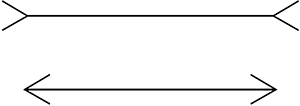

10.缪勒-莱尔错觉。

10. The Müller-Lyer illusion.

关于为什么上面的线条看起来更长，人们提出了各种各样的解释，但我们在此不必赘述。关键在于：*即使你知道这是一种视觉错觉，*两条线看起来仍然不等长。福多尔认为，这个简单的事实对于理解大脑的结构具有重要意义。因为它表明，两条线长度相等的信息存储在认知大脑的一个区域，而我们的感知机制无法访问该区域。如果视觉感知并非如此封闭，而是可以利用大脑中存储的所有信息，那么一旦你被告知两条线实际上长度相等，这种错觉就会立即消失。

Various explanations have been suggested for why the top line looks longer, but they need not concern us here. The point is this: the lines continue to look unequal in length *even when you know it’s an optical illusion*. According to Fodor, this simple fact has important implications for understanding the architecture of the mind. For it shows that the information that the two lines are equal in length is stored in a region of the cognitive mind to which our perceptual mechanisms do not have access. If visual perception was not encapsulated in this way, but could make use of all the information stored in the mind, then the illusion would disappear as soon as you were told that the lines were actually equal in length.

信息封装的另一个可能例子来自人类的恐惧症现象。以恐蛇症为例，这种恐惧症在人群中十分普遍。即使你知道某条蛇并不危险，例如，有人告诉你它的毒腺已被切除，你仍然很可能害怕它，并且不想去碰它。这种恐惧症通常可以通过训练克服，但这又是另一个话题了。关键在于，当你看到蛇时，大脑中负责产生恐惧反应的那部分无法获取“蛇不危险”这一信息。这表明，每个人体内可能都存在一个内置的、信息封装的“恐蛇症”模块。

Another possible example of information encapsulation comes from the phenomenon of human phobias. Consider ophidiophobia, or fear of snakes, which is widespread among humans. Even if you know that a particular snake isn’t dangerous, e.g. because you’ve been told that its poison glands have been removed, you are still quite likely to be scared of it and will not want to touch it. This sort of phobia can often be overcome by training, but that is a different matter. The key point is that the information that the snake isn’t dangerous is inaccessible to the part of your mind which produces in you the reaction of fear when you see a snake. This suggests that there may be an inbuilt, informationally encapsulated ‘fear of snakes’ module in every human being.

你或许会疑惑，为什么心智的模块化问题会成为哲学家们的话题。这难道不是一个科学事实的问题吗？心智是否具有模块化结构？某种程度上来说，这种说法没错，但这场争论涉及诸多哲学层面。其中之一便是如何计算认知任务和模块的数量。模块化理论的支持者认为，心智包含用于执行不同认知任务的专门模块；而反对者则否认这一点。

You may wonder why the modularity of mind issue is a matter for philosophers. Surely it is just a question of scientific fact whether the mind is modular or not? In a way this is true, but the debate has a number of philosophical dimensions. One concerns how to count cognitive tasks and modules. Advocates of modularity hold that the mind contains specialized modules for performing different cognitive tasks; their opponents deny this.

但是，我们如何判断两个认知任务是相同还是不同呢？面部识别是一个单一的认知任务，还是包含两个不同的认知任务：识别男性面孔和识别女性面孔？长除法和长乘法是不同的认知任务，还是它们都属于更一般的算术运算任务？这类问题属于概念性或哲学性问题，而非直接的经验性问题，它们对模块化之争至关重要。假设模块化理论的反对者提出实验证据，证明我们使用单一的认知能力来执行多种不同类型的认知任务。反对者可能会接受实验数据，但会辩称这些认知任务本质上是同一*类型*的，因此这些数据完全符合模块化理论。所以，为了明确模块化之争的本质，我们需要一种系统性的方法来统计认知任务和模块。

But how do we decide whether two cognitive tasks are the same or different? Is facial recognition a single cognitive task or does it comprise two distinct cognitive tasks: recognizing male faces and recognizing female faces? Are long division and multiplication different cognitive tasks, or are they both part of the more general task of doing arithmetic? Questions of this sort are conceptual or philosophical, rather than straightforwardly empirical, and are potentially crucial to the modularity debate. For suppose an opponent of modularity produces experimental evidence to show that we use a single cognitive capacity to perform many different types of cognitive task. Their opponent might accept the experimental data, but argue that the cognitive tasks in questions are all of the *same* type, and thus that the data are perfectly compatible with modularity. So in order for the modularity debate to be well defined, a principled way of counting cognitive tasks and modules is needed.

第二个哲学维度源于模块化理论的支持者和反对者都运用了先验论证以及直接的经验证据来支持各自的观点。福多本人认为，感知和语言或许是模块化的，但思维和推理却不是，因为它们是“整体性的”。为了理解福多的论证，假设你是一名陪审员，正在商议如何做出判决。你会如何进行这项任务？你会考虑的一点是被告的陈述是否逻辑一致——是否存在矛盾？你还会问自己，针对被告的证据究竟有多强。你在这里运用的推理技能——检验逻辑一致性和评估证据——是通用的；它们并非专门为特定案件而设计的。在陪审团服务中，你运用认知能力来判断被告是否有罪，这种认知能力并非特定领域专属，也并非强制性的——你必须有意识地思考被告是否有罪，并且可以随时停止思考，例如在午休时间。此外，也不存在信息封装。你的任务是综合考虑*所有因素来*判断被告是否有罪，因此，如果你认为某个背景信息与案件相关，你可能需要利用这些信息。例如，如果被告在交叉询问中出现紧张的抽搐，而你认为这种紧张的抽搐通常是犯罪的迹象，那么你很可能会在做出裁决时运用这种信念。因此，不存在任何你用来做出裁决的认知机制无法获取的信息（尽管法官可能会要求你忽略某些信息）。简而言之，并不存在一个专门用于判断被告是否有罪的模块。你运用的是你的一般智力来解决这个认知问题。

A second philosophical dimension arises because both proponents and opponents of modularity have employed a priori arguments, in addition to direct empirical evidence, in support of their view. Fodor himself argued that while perception and language are probably modular, thinking and reasoning cannot be since they are ‘holistic’. To understand Fodor’s argument, suppose you are a member of a jury deliberating over what verdict to return. How will you go about your task? One thing you will consider is whether the defendant’s story is logically consistent—is it free from contradiction? And you will ask yourself how strong the evidence against the defendant really is. The reasoning skills you apply here—testing for logical consistency and assessing evidence—are general; they are not specifically designed for use in jury service. So the cognitive capacities you bring to bear in deliberating the defendant’s guilt are not domain-specific. Nor is their operation mandatory—you have to consciously consider whether the defendant is guilty, and can stop doing so whenever you want to, e.g. during the lunch break. Finally, there is no information encapsulation either. Your task is to decide whether the defendant is guilty *all things considered*, so you may have to draw on any of the background information that you possess, if you consider it relevant. For example, if the defendant twitched nervously under cross-examination and you believe that nervous twitching is often a sign of guilt, you will probably draw on this belief in reaching your verdict. So there is no store of information which is inaccessible to the cognitive mechanisms you employ to reach your verdict (though the judge may tell you to ignore certain things). In short, there is no module for deciding whether a defendant is guilty. You tackle this cognitive problem using your general intelligence.

一些心理学家比福多尔走得更远，提出人类心智完全是模块化的；这被称为“大规模模块化假说”。大规模模块化假说的支持者认为，我们应该预期人类心智会呈现出模块化的组织结构。他们的主要论点源于达尔文的适应性进化论。人们普遍认为，人类心智是在更新世时期进化而来的，目的是为了让我们的原始人类祖先能够应对当时面临的社会和环境挑战。他们认为，模块化的组织结构是解决这些挑战并实现适应性行为的最有效方式。一组专门的模块，每个模块都针对特定任务进行专门设计，可以更快、更准确地解决问题。瑞士军刀的比喻在这里很贴切。显然，拥有分别用于开罐头、开瓶盖和拧螺丝的工具，比拥有一个可以完成所有这些任务的万能工具要好得多。同样，拥有分别用于面部识别、语言习得和择偶等功能的独立模块的心智，会比一个通用型的心智更高效。求解器。因此，从最优设计的角度来看，思维模块化是有利的，论点是这样的。

Some psychologists have gone further than Fodor and suggested that the mind is entirely modular; this is known as the ‘massive modularity hypothesis’. Proponents of massive modularity argue on general grounds that we should expect the human mind to exhibit a modular organization. Their main argument comes from considerations of Darwinian adaptiveness. The human mind is widely supposed to have evolved in the Pleistocene epoch, to allow our hominid ancestors to solve the social and environmental challenges they faced. The suggestion is that a modular organization provides the most efficient way of solving these challenges and so behaving adaptively. A set of dedicated modules, each specialized for a given task, allows faster and more accurate problem solving. The Swiss army knife analogy is relevant here. Clearly, having separate tools for can-opening, bottle-opening, and screw-driving is preferable to having a single all-purpose tool that can do each of these things. Similarly, a mind with separate modules for face recognition, language acquisition, and mate choice, for example, will be more efficient than one that is a general-purpose problem solver. So considerations of optimal design tell in favour of mental modularity, the argument goes.

一个相关的论点认为，人类不可能在一生中获取所有适应环境所需的信息。学习的机会实在太少。因此，大脑需要包含一些先天信息，这些信息被封装在一个模块中，使儿童能够发展出相应的认知技能，从而实现适应性行为。乔姆斯基的语言习得模块就说明了这一点。该模块包含了关于每种人类语言语法的先天信息，使儿童能够在极少的输入下习得一门语言。解决认知任务所需的信息与可通过学习获得的信息之间的这种“差距”经常被用来支持模块化的认知组织。然而，严格来说，这实际上是在论证大脑包含先天信息，而不是支持模块化本身。这些概念在逻辑上是不同的，但在实践中，模块化的支持者往往相信先天信息的存在，反之亦然。

A related argument holds that a human cannot possibly acquire all the information needed to behave adaptively in its own lifetime. The opportunities for learning are simply too few, it is argued. Therefore the mind needs to contain innate information, encapsulated in a module, which will allow the child to develop the appropriate cognitive skills and thus behave adaptively. Chomsky’s language acquisition module illustrates this point. The module contains innate information about the grammar of every human language, enabling the child to acquire a language given quite minimal input. This ‘gap’ between the information needed to solve a cognitive task and the information that can be acquired by learning is often used to argue in favour of a modular cognitive organization. Strictly speaking, though, it is an argument for the mind’s containing innate information, rather than for modularity per se. These are logically distinct ideas, but in practice defenders of modularity tend to believe in innate information and vice versa.

模块性和先天性之间的这种联系揭示了模块性辩论在哲学上具有重要意义的另一个方面。认为心灵包含先天信息的观点与传统的经验主义哲学截然相反，后者认为所有知识都来源于经验。在17和18世纪，约翰·洛克和大卫·休谟等经验主义者认为，人类出生时心灵就像一张“白板”，上面什么都没有。只有通过经验，人类才能获得概念和知识。这种经验主义学说由来已久，乍一看似乎显而易见。但乔姆斯基认为，他的语言习得模块包含了关于普遍语法的先天信息，这直接反驳了经验主义哲学的这一方面。如果乔姆斯基的论证是正确的——这是一个备受争议的观点——那么它提供了一个有趣的例子，说明科学发现如何能够为传统的哲学辩论提供信息。

This connection between modularity and innateness points to another respect in which the modularity debate is philosophically significant. The idea that the mind contains innate information is sharply at odds with traditional empiricist philosophy, according to which all knowledge comes from experience. In the 17th and 18th centuries, empiricists such as John Locke and David Hume argued that at birth the human mind is a ‘tabula rasa’, or blank slate, with nothing written on it. It is only through experience that a human comes to have concepts and knowledge. This empiricist doctrine is a venerable one, and at first sight strikes many as obviously true. But Chomsky argued that his language acquisition module, containing as it does innate information about universal grammar, directly disproves this aspect of the empiricist philosophy. If Chomsky’s argument is correct—a hotly debated point—it provides an interesting example of how scientific findings can inform traditional philosophical debates.

现在断言大规模模块化理论是否站得住脚还为时尚早。先验的论证（正反双方的论证）本身并不能解决问题；需要直接证据。福多本人就否定大规模模块化理论，因此他对认知心理学能否解释人类思维的运作机制持悲观态度。他认为只有模块化系统才能进行科学研究——非模块化系统由于信息封装性差，建模难度更大。因此，福多认为认知心理学家的最佳研究策略是专注于感知和语言，而忽略思维和推理。但不出所料，福多的这一观点极具争议。

It is too early to say whether the massive modularity thesis will prove tenable. The a priori arguments (for and against) cannot themselves settle the issue; direct evidence is needed. Fodor himself rejects massive modularity, and as a result is pessimistic about the possibility of cognitive psychology ever explaining the workings of the human mind. He believes that only modular systems can be studied scientifically—non-modular systems, because they are not informationally encapsulated, are much more difficult to model. So according to Fodor the best research strategy for cognitive psychologists is to focus on perception and language, leaving aside thinking and reasoning. But unsurprisingly, this aspect of Fodor’s thought is highly controversial.

# 第七章

# Chapter 7

# 科学及其批评者

# Science and its critics

许多人理所当然地认为科学是一件好事，原因显而易见。毕竟，科学为我们带来了电力、安全的饮用水、青霉素和航空旅行——所有这些都无疑造福了人类。然而，尽管科学对人类福祉做出了如此令人瞩目的贡献，它也并非没有批评者。有人认为社会在科学上投入过多资金，而忽视了艺术；也有人指出，科学赋予了我们一些我们本可以避免的技术能力，例如大规模杀伤性武器。一些女权主义者认为科学本质上带有男性偏见；有宗教信仰的人常常觉得科学威胁到了他们的信仰；而人类学家则指责西方科学傲慢地认为自己凌驾于土著文化的知识和信仰之上。以上并非科学所遭受的全部批评，但在此，我们将重点关注其中三个具有特殊哲学意义的批评。

Many people take it for granted that science is a good thing, for obvious reasons. After all, science has given us electricity, safe drinking water, penicillin, and air travel—all of which have undoubtedly benefited humanity. But despite these impressive contributions to human welfare, science is not without its critics. Some argue that society spends too much money on science at the expense of the arts; others observe that science has given us technological capabilities we would be better off without, e.g. weapons of mass destruction. Some feminists argue that science is inherently male-biased; those of religious persuasion often feel that science threatens their faith; and anthropologists have accused Western science of arrogantly assuming its superiority over the knowledge and beliefs of indigenous cultures. This does not exhaust the list of criticisms to which science has been subject, but here we confine our attention to three that are of particular philosophical interest.

# 科学主义

# Scientism

“科学”一词在现代社会获得了一种特殊的象征意义。如果有人指责你的行为不科学，他们几乎肯定是在批评你。科学的行为是理性的、值得称赞的；不科学的行为是非理性的、应受鄙视的。我们很难理解为什么人们会把某些事情称为科学的。“科学家”一词或许带有这些含义，但这可能与科学在现代社会中享有的崇高地位有关。科学家被视为专家，人们经常就重要的社会问题征求他们的意见。当然，人人都知道科学家有时也会犯错；例如，20世纪90年代初，英国政府的科学顾问宣称“疯牛病”对人类没有威胁，但后来却被证明犯下了悲剧性的错误。然而，这类偶尔出现的失误并不会动摇公众对科学的信任，也不会影响人们对科学家的尊重。在许多国家，科学家的地位很像过去的宗教领袖：他们拥有普通民众无法企及的专业知识。

The word ‘scientific’ has acquired a peculiar cachet in modern times. If someone accuses you of behaving unscientifically, they are almost certainly criticizing you. Scientific conduct is rational and praiseworthy; unscientific conduct is irrational and worthy of contempt. It is difficult to know why calling something scientific should carry these connotations, but it probably relates to the high status which science holds in modern society. Scientists are treated as experts, their opinions regularly sought on matters of social importance. Of course, everybody recognizes that scientists sometimes get it wrong; for example, scientific advisers to the British government in the early 1990s declared that ‘mad cow’ disease posed no threat to humans, only to be proved tragically mistaken. But occasional hiccups of this sort tend not to shake the public faith in science, nor the esteem in which scientists are held. In many countries, scientists are viewed much as religious leaders used to be: possessors of specialized knowledge that is inaccessible to the laity.

“科学主义”是某些哲学家用来贬义地描述他们眼中的科学崇拜，或者说是对现代科学过度崇敬的态度。科学主义的反对者认为，科学并非唯一有效的智力活动形式，也并非理解世界的唯一途径。他们经常强调，他们并非反对科学本身；他们反对的是科学方法必然适用于所有学科的假设。因此，他们的目标并非攻击科学，而是通过否定科学知识就是全部知识的观点来对其进行反思。

‘Scientism’ is a pejorative term used by some philosophers to describe what they see as science worship, or an over-reverential attitude towards modern science. Opponents of scientism argue that science is not the only valid form of intellectual endeavour, and not the only way of understanding the world. They often stress that they are not anti-science per se; what they are opposed to is the assumption that scientific methods are necessarily applicable to every subject matter. So their aim is not to attack science but to put it in place, by rejecting the idea that scientific knowledge is all the knowledge there is.

科学主义是一个相当模糊的理论，而且由于这个词带有贬义，很少有人会公开承认自己信奉它。然而，类似崇拜科学的现象在知识界却是真实存在的。这未必是件坏事——或许科学确实值得被崇拜。但这无疑是一种真实存在的现象。当代英语哲学（科学哲学只是其中的一个分支）经常被指责存在科学崇拜。尽管哲学与数学和科学有着密切的历史联系，但传统上它被视为人文学科，这并非没有道理。因为哲学探讨的问题，例如知识的本质、道德以及人类福祉等，似乎与数学和科学无关。这些问题无法用科学方法解决。没有任何科学分支能够告诉我们应该如何生活、什么是知识，或者人类的繁荣包含哪些要素；这些本质上都是哲学问题。

Scientism is a rather vague doctrine, and, given that the term has a pejorative usage, few would explicitly admit to believing it. Nonetheless, something quite like science worship is a genuine feature of the intellectual landscape. This is not necessarily a bad thing—perhaps science deserves to be worshipped. But it is certainly a real phenomenon. One field which is often accused of science worship is contemporary anglophone philosophy (of which philosophy of science is just one branch). Traditionally philosophy is regarded as a humanities subject, despite its close historical links to mathematics and science, and with good reason. For philosophy asks questions about the nature of knowledge, morality, and human well-being, for example, which do not seem soluble by scientific methods. No branch of science tells us how we should lead our lives, what knowledge is, or what human flourishing involves; these are quintessentially philosophical questions.

鉴于此，一些哲学家坚持认为科学是通往知识的唯一合法途径，这或许令人惊讶。他们认为，无法通过科学手段解决的问题根本就不是真正的问题。20世纪英国著名哲学家伯特兰·罗素也赞同这一观点，他写道：“凡是可获得的知识，都必须通过科学方法获得；科学无法发现的，人类也无法知晓。”这一观点的依据在于一种名为“自然主义”的学说，它强调我们人类是自然世界不可分割的一部分，而不是像过去人们认为的那样，与自然世界分离。既然科学研究的是整个自然世界，那么它理应能够揭示关于人类生存状态的全部真相，哲学也就无从下手了。按照这种观点，哲学本身并没有独特的研究对象。如果说哲学有什么作用的话，那就是“澄清科学概念”——扫清障碍，以便科学家们能够继续他们的工作。

In the light of this, it may seem surprising that some philosophers insist that science is the only legitimate path to knowledge. Questions that cannot be resolved by scientific means are not genuine questions at all, they hold. This view was endorsed by the famous 20th-century English philosopher Bertrand Russell, who wrote: ‘whatever knowledge is attainable, must be attained by scientific methods; and what science cannot discover, mankind cannot know’. The grounds for the view lie in a doctrine called ‘naturalism’, which stresses that we human beings are part and parcel of the natural world, not something apart from it, as was once believed. Since science studies the whole of the natural world, surely it should be capable of revealing the complete truth about the human condition, leaving nothing left for philosophy? On this view, philosophy has no distinctive subject matter of its own. Insofar as it serves a useful role at all, it involves ‘clarifying scientific concepts’—clearing the brush so that scientists can get on with their work.

不出所料，许多哲学家反对哲学从属于科学；这正是他们反对科学主义的原因之一。他们认为，哲学探究拥有其独特的方法，能够揭示科学无法揭示的真理。持这种观点的人认为，哲学应当力求与科学保持*一致*，也就是说，哲学不应提出与科学教导相冲突的主张。他们通常也承认，人类是自然秩序的一部分，因此不能凌驾于科学的范畴之上。但他们指出，这并不意味着科学是了解世界的唯一合法途径。

Not surprisingly, many philosophers reject this subordination of their discipline to science; this is one source of opposition to scientism. They argue that philosophical enquiry has its own proprietary methods, which can reveal truths of a sort that science cannot. Proponents of this view allow that philosophy should aim to be *consistent* with the sciences, in the sense of not advancing claims which conflict with what science teaches us. And they typically accept that we humans are part of the natural order, so not exempt from the scope of science. But it does not follow, they argue, that science is the only legitimate source of knowledge about the world.

这些哲学探究方法究竟是什么？它们包括逻辑推理、思想实验以及所谓“概念分析”，是指通过依赖我们对特定案例是否属于某个概念的直觉来界定该概念。例如，一个经典的哲学问题是：知识是否等同于真信念？大多数哲学家认为答案是否定的，理由是我们可以构建这样一些案例：一个人确实相信某个命题，但却不能说他真正了解它。（例如，假设你相信现在是六点十分，因为你的手表显示的时间是六点十分；事实上你的手表坏了，但碰巧时间确实*是*六点十分！因此，你的信念是正确的，但直觉上你并不*知道*现在是六点十分，你只是“运气好”。）所以，通过概念分析，我们可以确定知识和真信念并非同一概念——这是一个实质性的哲学真理。这只是一个例子；但它说明了哲学探究如何运用其自身的非科学方法获得真正的知识。

What exactly are these methods of philosophical enquiry? They include logical reasoning, the use of thought experiments, and what is called ‘conceptual analysis’, which tries to delimit a particular concept by relying on our intuitions about whether a particular case falls under it. For example, a classical philosophical question asks whether knowledge is identical to true belief. Most philosophers say that the answer is ‘no’, on the grounds that we can construct cases in which a person does truly believe a particular proposition but cannot be said to know it. (For example, suppose you believe that it is ten past six because that is what your watch says; in fact your watch is broken, but by chance the time *is* actually ten past six! Your belief is therefore true, but intuitively you did not *know* that it was ten past six as you simply ‘got lucky’.) So by using conceptual analysis, we can establish that knowledge and true belief are not identical—which is a substantive philosophical truth. This is just one example; but it illustrates the idea that philosophical enquiry can yield genuine knowledge using its own non-scientific methods.

这场辩论该如何评价？一方面，的确存在一些哲学问题，它们看似真切，超越了任何科学的范畴，并且能够用哲学家独特的方法来解答。然而，另一方面，哲学史上讨论过的许多问题，例如关于感知、想象和记忆的问题，最终都归属于经验科学，尤其是心理学的范畴。事实上，几个世纪以来，被归类为“哲学”的问题范围一直在缩小，因为越来越多的问题被科学所涵盖。此外，认为哲学探究和科学探究是相互独立的，各自依赖自身方法的观点，也被批评为一厢情愿的想法；反对者指出，尽管科学领域无疑取得了进步，但哲学领域的进步却难以察觉。

How should this debate be assessed? On the one hand, there are certainly examples of philosophical questions which appear to be genuine, to lie outside the provenance of any science, and to be answerable by the distinctive methods of philosophers. However, against this, many of the questions discussed in the history of philosophy, e.g. about perception, imagination, and memory, have turned out to be matters for the empirical sciences, in particular psychology. Indeed the pool of questions classed as ‘philosophical’ has shrunk over the centuries, as more and more get appropriated by science. Moreover, the idea that philosophical enquiry and scientific enquiry are autonomous, each relying on their own methods, has been criticized as wishful thinking; opponents point out that while there is certainly progress in science, progress in philosophy is rather harder to discern.

一个类似的问题涉及自然科学和社会科学之间的关系。正如哲学家抱怨其学科中存在“科学崇拜”一样，社会科学家也抱怨其学科中存在“自然科学崇拜”。人们常常认为，自然科学，例如……物理学、化学和生物学的发展水平高于经济学、社会学和人类学等社会科学；前者能够构建具有强大预测能力的精确定律，而后者通常无法做到这一点。这是为什么呢？这不太可能是因为自然科学家比社会科学家更聪明。一个可能的解释是，自然科学的*方法*更胜一筹。如果这是正确的，那么社会科学要想迎头赶上，就必须效仿自然科学的方法。在某种程度上，这种情况已经发生。社会科学中数学的日益普及可能部分源于这种态度。当伽利略将数学语言应用于运动描述时，物理学取得了巨大的进步；因此，人们很容易认为，如果社会科学也能找到类似的“数学化”方法，那么它或许也能取得类似的飞跃。

An analogous issue concerns the relation between the natural and social sciences. Just as philosophers complain of ‘science worship’ in their discipline, so social scientists complain of ‘natural science worship’ in theirs. It is often felt that natural sciences such as physics, chemistry, and biology are in a more advanced state than social sciences such as economics, sociology, and anthropology; the former can formulate precise laws with great predictive power, while the latter usually cannot. Why should this be so? It can hardly be because natural scientists are smarter than social scientists. One possible answer is that the *methods* of the natural sciences are superior. If this is correct, then what the social sciences need to do to catch up is to ape the methods of the natural sciences. To some extent this has already happened. The increasing use of mathematics in the social sciences may be partly a result of this attitude. Physics made a great leap forward when Galileo took the step of applying mathematical language to the description of motion; so it is tempting to think that a comparable leap forward might be achievable in the social sciences if a comparable way of ‘mathematicizing’ their subject matter can be found.

然而，一些社会科学家反对以这种方式仰望自然科学，他们认为自然科学的方法未必适用于研究社会现象。他们通常否认社会科学相对于自然科学而言存在不足，并指出社会现象的复杂性以及通常无法进行受控实验的事实，意味着找到具有预测能力的精确规律并非衡量成功的合适标准。

However, some social scientists resist the suggestion that they should look up to the natural sciences in this way, arguing that the methods of natural science are not necessarily appropriate for studying social phenomena. They typically deny that the social sciences are impoverished vis-à-vis the natural sciences, pointing out that the complexity of social phenomena, and the fact that controlled experiments usually cannot be done, mean that finding precise laws with predictive power is not an appropriate benchmark of success.

这一论点的颇具影响力的版本源于19世纪德国社会学家威廉·狄尔泰和马克斯·韦伯。他们认为，必须从行为者的视角来理解社会现象。社会现象与自然现象的区别在于，前者是人类有意行为的结果。因此，社会科学研究需要一种特殊的理解方式，称为*“理解”* （verstehen ）；这涉及试图把握社会行为对行为者而言的主观意义。例如，研究宗教仪式的民族学家需要理解该仪式对参与者的意义；纯粹的“客观”分析，例如运用自然科学方法进行的分析，无法真正理解仪式，因为它忽略了仪式意义这一关键问题。因此，理解（*verstehen* ）理论确立了自然科学和社会科学之间的显著差异。该理论对人类学和社会学的发展产生了深远的影响，尤其是在20世纪。

An influential version of this argument derives from the 19th-century German sociologists Wilhelm Dilthey and Max Weber. They argued that social phenomena must be understood from the viewpoint of the actor(s) responsible for them. What distinguishes social from natural phenomena is that the former are the result of the intentional action of humans. Thus a special type of understanding, called *verstehen*, is needed for social scientific enquiry; this involves trying to grasp the subjective meaning that a social action has for the actor. For example, an anthropologist studying a religious ritual needs to understand the significance that the ritual has for the participants; a purely ‘objective’ analysis, of the sort that could be had by applying the methods of natural science, cannot yield a genuine understanding of the ritual, since it neglects the crucial matter of the ritual’s meaning. The doctrine of *verstehen* thus posits a sharp discontinuity between the natural and social sciences. The doctrine had a significant influence on the development of anthropology and sociology, in particular, in the 20th century.

科学主义问题以及与之相关的自然科学与社会科学之争都不容易解决。部分原因是，我们并不完全清楚“科学方法”或“自然科学方法”究竟包含哪些内容——这一点在辩论双方中常常被忽略。如果我们想知道科学方法是否适用于所有学科，或者是否能够回答所有重要问题，显然我们需要了解这些方法究竟*是*什么。但正如我们所见，这个问题远比表面看起来复杂。我们当然知道科学探究的一些主要特征：实验检验、观察、理论构建和归纳推理。但这一系列特征并不能提供“科学方法”的精确定义。而且，这样的定义是否能够给出也并非显而易见。科学随着时间的推移而快速发展，因此，认为存在一种固定不变的“科学方法”，并被所有科学学科在任何时候都使用，这种假设并非必然成立。但这种假设既隐含在“科学是通往知识的唯一途径”这一论断中*，也*隐含在“有些问题无法用科学方法解答”这一反驳论断中。这表明，至少在某种程度上，关于科学主义的争论可能建立在一个错误的假设之上。

Neither the scientism issue nor the parallel issue about natural and social science is easy to resolve. In part, this is because it is not fully clear what exactly the ‘methods of science’, or the ‘methods of natural science’, actually comprise—a point that is often overlooked by both sides in the debate. If we want to know whether the methods of science are applicable to every subject matter, or whether they are capable of answering every important question, we obviously need to know what exactly those methods *are*. But as we have seen, this is less straightforward a question than it seems. Certainly we know some of the main features of scientific enquiry: experimental testing, observation, theory construction, and inductive inference. But this list does not provide a precise definition of ‘the scientific method’. Nor is it obvious that such a definition could be provided. Science changes rapidly over time, so the assumption that there is a fixed, unchanging ‘scientific method’, used by all scientific disciplines at all times, is not inevitable. But this assumption is implicit both in the claim that science is the only route to knowledge *and* in the counter-claim that some questions cannot be answered by scientific methods. This suggests that, to some extent at least, the debate about scientism may rest on a false presupposition.

# 科学与宗教

# Science and religion

科学与宗教之间的紧张关系由来已久。或许最著名的例子就是伽利略与天主教会的冲突。1633年，宗教裁判所强迫伽利略公开放弃他的哥白尼观点，并判处他在佛罗伦萨软禁多年。教会反对哥白尼的理论，当然是因为它违背了圣经。近年来，最引人注目的科学与宗教冲突莫过于美国达尔文主义者和“智能设计论”支持者之间的激烈争论，这也是本文的重点。

The tension between science and religion is old. Perhaps the best-known example is Galileo’s clash with the Catholic Church. In 1633 the Inquisition forced Galileo to publicly recant his Copernican views and condemned him to spend his last years under house arrest in Florence. The Church objected to the Copernican theory because it contravened the holy Scriptures, of course. In recent years, the most prominent science/religion clash has been the bitter dispute between Darwinists and proponents of ‘intelligent design’ in the United States, which will be our focus here.

神学界对达尔文进化论的反对由来已久。 1859年*《物种起源》*出版后，立即遭到英国教会人士的批评。原因显而易见：达尔文的理论认为，包括人类在内的所有现存物种，都是在漫长的岁月中由共同祖先演化而来。这一理论显然与《创世记》相悖，《创世记》记载上帝在六天内创造了所有生物。一些达尔文主义者试图调和他们对进化论的信仰与基督教信仰，他们认为《创世记》不应按字面意思解读，而应视为寓言或象征性的。然而，在美国，许多福音派新教徒不愿为了迎合科学发现而改变他们的宗教信仰。他们坚持认为圣经中关于创世的记载是字面意义上的真实，因此达尔文的进化论完全错误。

Theological opposition to Darwin’s theory of evolution is nothing new. When *The Origin of Species* was published in 1859, it immediately attracted criticism from churchmen in England. The reason is obvious: Darwin’s theory maintains that all current species, including humans, have descended from common ancestors over a long period of time. This theory clearly contradicts the Book of Genesis, which says that God created all living creatures over a period of six days. Some Darwinians have tried to reconcile their belief in evolution with their Christian faith by arguing that the Book of Genesis should not be interpreted literally—it should be regarded as allegorical, or symbolic. However, in the USA, many evangelical Protestants have been unwilling to bend their religious beliefs to fit scientific findings. They insist that the biblical account of creation is literally true, and that Darwin’s theory of evolution is therefore completely wrong.

这种观点被称为“神创论”，在美国约有40%的成年人接受它。神创论是一股强大的政治力量，多年来对美国高中生物教学产生了相当大的影响，这令科学家们感到沮丧。由于美国宪法禁止在公立学校教授宗教，于是“神创论科学”应运而生——它声称圣经中的创世记述比达尔文的进化论更能科学地解释地球上的生命。因此，教授圣经创世论并不违反宪法禁令，因为它属于科学范畴，而非宗教！1981年，阿肯色州通过了一项法律，要求生物教师必须向学生讲授圣经创世论。进化论和神创论应享有“同等时间”。然而，这一裁决在第二年被一位联邦法官推翻，1987年，最高法院裁定在公立学校教授神创论违宪。

This opinion is known as ‘creationism’, and is accepted by some 40 per cent of the adult population in the USA. Creationism is a powerful political force, and over the years has had considerable influence on the teaching of biology in American high schools, to the dismay of scientists. Since the American constitution prohibits the teaching of religion in public schools, ‘creation science’ was invented—which claims that the biblical account of creation is a better scientific explanation of life on earth than Darwin’s theory of evolution. So teaching biblical creation does not violate the constitutional ban, for it counts as science, not religion! In 1981 a law was passed in Arkansas calling for biology teachers to give ‘equal time’ to evolution and creation science. However this was overruled by a federal judge the following year, and in 1987 a Supreme Court judgment ruled that teaching creation science in public schools was unconstitutional.

在这些法律诉讼失败后，创造科学运动巧妙地将自己重新包装成“智能设计”的代名词。这个名称暗指一种古老的上帝存在论证，即“设计论证”。该论证认为，复杂生物体的存在只能通过假设它们是由一位智慧的神创造的来解释；这位神通常被认为是基督教的上帝。设计论证在达尔文时代之前曾是主流思想的一部分，但当然已被当代生物学家所否定。智能设计的支持者重新拾起了这一论证，声称生物体展现出“不可简化的复杂性”，这种复杂性不可能通过达尔文的进化方式产生，因此证明了上帝的创造。一个“不可简化的复杂”系统指的是一个由多个相互作用的组成部分构成的系统，每个组成部分对于系统的正常运作都至关重要——移除或改变其中任何一个部分，系统都会崩溃。生物有机体，乃至单个细胞，从这个意义上讲确实很复杂，因为它们的功能依赖于许多生化成分的协调活动。智能设计论者认为，这种相互依存关系不可能通过自然选择进化而来。

Following these legal defeats, the creation science movement cleverly rebranded itself under the label ‘intelligent design’. The name is an allusion to an old argument for the existence of God, known as the ‘argument from design’, which says that the existence of complex biological organisms can only be explained by supposing that an intelligent deity created them; this deity is usually identified with the Christian God. The argument from design was part of the intellectual mainstream in the pre-Darwinian era, but is of course rejected by contemporary biologists. Proponents of intelligent design have resuscitated the argument, claiming that biological organisms exhibit ‘irreducible complexity’ which could not have evolved by Darwinian means, and is thus proof of God’s handiwork. An ‘irreducibly complex’ system is one with a number of interacting parts each of which is critical to the system’s functioning—remove or alter any one of the parts and the system breaks down. It is true that biological organisms, and indeed individual cells, are complex in this sense, as their functioning depends on the coordinated activity of many biochemical components. This sort of interdependence could not have evolved by natural selection, claim the intelligent design camp.

尽管这种论点最近备受关注，但它不过是旧瓶装新酒。在*《物种起源》*中，达尔文本人也曾思考过脊椎动物的眼睛这种高度复杂的器官是如何通过自然选择进化而来的，他指出，乍一看这似乎“荒谬”。然而，达尔文认为，可以通过想象一个演化过程来解决这个难题：从简单的眼睛（或许只有几个感光细胞）到现代眼睛，眼睛经历了一系列渐进式的改进，每一次改进都赋予了眼睛一定的选择优势。这样一来，一个结构极其复杂、精细的器官，通过自然选择进化而来，便能解释这一难题。眼睛的某些组成部分可能通过自然选择进化而来。达尔文本人也只能猜测眼睛进化的中间阶段。但近期的科学研究通过对脊椎动物胚胎发育的研究以及详细的基因分析，对眼睛进化的可能阶段顺序提供了详尽的见解。因此，眼睛不可能通过自然选择产生的观点已被成功驳斥。由此可见，没有任何证据支持生物体所展现的任何特征不可能是进化过程的结果。

Despite its recent prominence, this argument is old wine in new bottles. In *The Origin of Species*, Darwin himself wondered how the vertebrate eye, a highly complex organ, might have evolved by natural selection, noting that at first blush it seems ‘absurd’. However, Darwin believed that the difficulty could be resolved by imagining a sequence leading from a simple eye (perhaps just a few light-sensitive cells) to modern eyes by a gradual series of incremental improvements, each of which conferred a selective advantage. In this way an organ of great complexity, with finely tuned components, could have evolved by natural selection. Darwin himself could only guess as to what the intermediate stages of eye evolution were. But recent scientific work has offered detailed insight into the probable sequence of stages, based on studying the embryonic development of the eye, and performing detailed genetic analyses, across vertebrate species. So the suggestion that the eye could not have arisen by natural selection has been successfully rebutted. The moral generalizes: there is no evidence to support the idea that organisms exhibit any features that could not have resulted from an evolutionary process.

除了强调“不可简化的复杂性”之外，智能设计论的支持者还试图从其他方面削弱达尔文的世界观。他们认为达尔文主义的证据尚不充分，因此不应将其视为既定事实，而应将其视为“仅仅是一种理论”。此外，他们还关注达尔文主义者内部的各种争论，并抓住个别生物学家的不当言论大做文章，试图证明反对进化论在科学上是合理的。他们最终得出结论：既然达尔文主义“仅仅是一种理论”，那么学生也应该接触其他理论，例如所有生物都是由一位智慧的神创造的理论。

In addition to their emphasis on ‘irreducible complexity’, proponents of intelligent design have tried to undermine the Darwinian worldview in other ways. They argue that the evidence for Darwinism is inconclusive, so Darwinism should not be regarded as established fact but rather as ‘just a theory’. In addition, they have focused on various internal disputes among Darwinians, and picked on a few incautious remarks by individual biologists, in an attempt to show that disagreeing with the theory of evolution is scientifically respectable. They conclude that since Darwinism is ‘just a theory’, students should be exposed to alternative theories too—such as the theory that an intelligent deity created all living organisms.

从某种意义上说，达尔文主义“仅仅是一种理论”而非已被证实的“事实”是完全正确的。正如我们在第二章中看到的，从严格意义上讲，我们永远无法*证明*一个科学理论是正确的，因为从数据推导出理论的过程总是非演绎性的。但这只是一般性的观点——它与进化论本身无关。同样地，我们也可以说地球绕太阳转、水是由H₂O组成的、以及物体在无支撑状态下会下落都“仅仅是一种理论” <sub>，</sub>因此应该向学生展示这些理论的替代方案。但智能设计论的支持者并没有这样论证。他们并非对整个科学持怀疑态度，而是对进化论本身持怀疑态度。因此，如果他们的立场要站得住脚，那么……不能仅仅因为我们的数据不能保证达尔文理论的正确性就断定结论正确。因为同样的道理也适用于所有科学理论，实际上也适用于大多数常识性信念。

In a way, it is quite correct that Darwinism is ‘just a theory’ and not proven fact. As we saw in Chapter 2, it is never possible to *prove* that a scientific theory is true, in the strict sense of proof, for the inference from data to theory is invariably non-deductive. But this is a general point—it has nothing to do with the theory of evolution per se. By the same token, we could argue that it is ‘just a theory’ that the earth goes round the sun, or that water is made of H<sub>2</sub>O, or that unsupported objects tend to fall, so students should be presented with alternatives to each of these. But proponents of intelligent design do not argue this. They are not sceptical about science as a whole, but about the theory of evolution in particular. So if their position is to be defensible, it cannot simply turn on the point that our data doesn’t guarantee the truth of Darwin’s theory. For the same is true of every scientific theory, and indeed of most commonsense beliefs too.

另一种智能设计论的论点是，化石记录并不完整，尤其是在智人祖先的*化石*方面。这种说法不无道理。进化论者长期以来一直对化石记录中的空白感到困惑。一个长期存在的难题是，为什么“过渡化石”（即介于两个物种之间的过渡生物化石）如此稀少。如果像达尔文的理论所言，后来的物种是由早期物种进化而来，那么过渡化石理应很常见才对。然而，这并不能成为反对达尔文理论的有力论据。因为化石并非进化论的唯一证据来源，甚至并非主要证据来源。其他证据来源包括比较解剖学、胚胎学、生物地理学和遗传学。例如，人类和黑猩猩拥有98%的相同DNA。如果进化论是正确的，那么这一事实以及成千上万个类似的现象就完全说得通，因此构成了支持进化论的有力证据。当然，智能设计论的支持者也可以解释这一事实，认为设计者出于自身的原因选择使人类和黑猩猩在基因上相似。但这种“解释”的可能性恰恰表明，达尔文的理论并非由现有证据逻辑推导而来，因此原则上可以编造出其他解释。这种方法论上的论点是正确的，但这并不能说明达尔文主义有何特殊之处。

Another intelligent design argument is that the fossil record is patchy, particularly when it comes to the supposed ancestors of *Homo sapiens*. There is some truth in this charge. Evolutionists have long puzzled over the gaps in the fossil record. One persistent puzzle is why there are so few ‘transition fossils’—of creatures intermediate between two species. If later species evolved from earlier ones as Darwin’s theory asserts, surely transition fossils should be common? However this is not a good argument against Darwin’s theory. For fossils are not the only or even the main source of evidence for the theory of evolution. Other sources include comparative anatomy, embryology, biogeography, and genetics. Consider for example the fact that humans and chimpanzees share 98 per cent of their DNA. This and thousands of similar facts make perfect sense if the theory of evolution is true, and thus constitute excellent evidence for the theory. Of course, a proponent of intelligent design can also explain this fact, by saying that the designer chose to make humans and chimpanzees genetically similar for reasons of his (or her) own. But the possibility of giving ‘explanations’ of this sort simply shows that Darwin’s theory is not logically entailed by the evidence, so in principle other explanations can be concocted. This methodological point is correct, but shows nothing special about Darwinism.

尽管智能设计论阵营的论点完全站不住脚，但这场争议确实引发了关于科学教育的严肃问题。在世俗教育体系中，应该如何处理科学与信仰之间的冲突？谁应该决定高中科学课程的内容？如果家长不希望自己的孩子学习进化论或其他科学知识，国家是否应该凌驾于他们的意愿之上？这些问题通常很少引起公众的关注。但达尔文主义与智能设计之间的冲突使它们走到了聚光灯下。

Though the arguments of the intelligent design camp are uniformly unsound, the controversy does raise serious questions concerning science education. How should the tension between science and faith be dealt with in a secular education system? Who should determine the content of high-school science classes? Should parents who don’t want their children to be taught about evolution, or some other scientific matter, be overruled by the state? These questions normally receive little public attention, but the clash between Darwinism and intelligent design has brought them to the fore.

# 科学是价值中立的吗？

# Is science value-free?

人人都认同，科学知识有时会被用于不道德的目的——例如制造核武器和化学武器。但这些案例并不能证明科学知识本身在伦理上存在问题。真正不道德的是人们如何*运用*这些知识。事实上，许多哲学家认为，谈论科学或科学知识本身是否合乎伦理毫无意义。因为科学关注的是事实，而事实本身并不具有伦理意义。关键在于我们如何运用这些事实，这才是对错、道德与否的体现。从这个角度来看，科学本质上是一种*价值中立的*活动——它的作用仅仅是提供关于世界的信息。至于社会如何运用这些信息，则是另一回事。

Everybody would agree that scientific knowledge has sometimes been used for unethical ends—to make nuclear and chemical weapons, for example. But such cases do not show that there is something ethically objectionable about scientific knowledge itself. It is the *use* to which that knowledge is put that is unethical. Indeed many philosophers would say that it makes no sense to talk about science or scientific knowledge being ethical or unethical per se. For science is concerned with facts, and facts in themselves have no ethical significance. It is what we do with those facts that is right or wrong, moral or immoral. On this view, science is essentially a *value-free* activity—its job is just to provide information about the world. What society chooses to do with that information is another matter.

并非所有哲学家都接受这种将科学视为价值中立的观点，也不接受其所基于的事实/价值二分法。一些哲学家认为，科学探究总是带有价值判断的色彩。这种观点的一个论据源于一个显而易见的事实：科学家必须选择研究对象——不可能同时考察所有事物。因此，他们必须对不同研究对象的相对重要性做出判断，而这些判断在某种程度上也属于价值判断。另一个论据源于这样一个事实：任何一组数据原则上都可以用多种方式解释。因此，科学家对理论的选择永远无法完全由其数据决定。一些哲学家认为，这表明价值总是与理论选择息息相关，因此科学不可能做到价值中立。第三个论据是，科学知识无法像价值中立所要求的那样与其预期应用脱钩。在这种观点看来，将科学家想象成不带任何偏见、纯粹为了研究而研究，未加任何思考，未免过于天真。因为它具有实际应用价值。如今许多科学研究都由私营部门资助，这一事实也为这种观点提供了一定的佐证。

Not all philosophers accept this picture of science as neutral with respect to questions of value, nor the underlying fact/value dichotomy on which it rests. Some claim that scientific enquiry is invariably laden with value judgements. One argument for this stems from the obvious fact that scientists have to choose what to study—not everything can be examined at once. So judgements about the relative importance of different possible objects of study have to be made, and these are value judgements, in a weak sense. Another argument stems from the fact that any set of data can in principle be explained in more than one way. A scientist’s choice of theory will thus never be uniquely determined by their data. Some philosophers take this to show that values are invariably involved in theory choice, and thus that science cannot be value-free. A third argument is that scientific knowledge cannot be divorced from its intended applications in the way that value-freedom would require. On this view, it is naive to picture scientists as disinterestedly doing research for its own sake, without a thought for its practical applications. The fact that much scientific research today is funded by the private sector lends some credence to this view.

尽管这些论点很有趣，但它们都有些抽象——它们试图表明科学原则上不可能做到价值中立，而不是具体指出价值在科学中发挥作用的案例。不过，也确实有人提出了关于科学存在价值倾向的具体指控。本文将重点讨论两个例子，一个来自心理学/生物学，另一个来自医学。

Though interesting, these arguments are all somewhat abstract—they seek to show that science could not be value-free as a matter of principle, rather than identifying actual cases of values playing a role in science. But specific allegations of value-ladenness have also been made. Here we focus on two examples, one from psychology/biology and the other from medicine.

我们的第一个案例涉及进化心理学，这门学科试图运用达尔文的进化论原理来理解人类的心理构成及其行为。乍一看，这个项目似乎完全合理。因为人类也只是另一种动物，而生物学家们一致认为，达尔文的理论可以解释许多动物行为及其心理基础。例如，老鼠本能地害怕猫，这显然可以用达尔文的理论来解释。在过去，具有这种本能恐惧的老鼠往往比没有这种恐惧的老鼠留下更多的后代，因为后者更容易被捕食；假设这种本能是遗传的，并因此从父母传给后代，那么经过许多代，它就会在种群中传播开来。进化心理学家认为，人类心理的许多方面都可以用类似的达尔文理论来解释。

Our first case concerns the discipline of evolutionary psychology, which tries to understand the psychological make-up of humans, and their resulting behaviour, by applying Darwinian principles. At first blush this project sounds perfectly reasonable. For humans are just another species of animal, and biologists agree that Darwinian theory can explain a lot about animal behaviour and its psychological underpinnings. For example, there is an obvious Darwinian explanation for why mice have an instinctive fear of cats. In the past, mice with this instinctive fear tended to leave more offspring than ones without, as the latter got eaten; assuming that the instinct was genetically based, and thus transmitted from parents to offspring, over many generations it would have spread through the population. Evolutionary psychologists believe that many aspects of human psychology can be given a Darwinian explanation of this sort.

举例来说，以人类的择偶偏好为例。有证据表明，男性和女性在择偶标准上存在系统性差异。（这一证据的强度尚存争议。）大卫·巴斯进行的一项大型跨文化调查发现，男性平均而言更倾向于选择比自己年轻的女性伴侣，并且伴侣的年龄最好接近女性的生育高峰期（约24岁）。相比之下，女性则更倾向于嫁给比自己年长的男性。此外，外貌吸引力对男性而言更为重要，而女性则不然。对女性而言，收入潜力更为重要。巴斯和其他进化心理学家认为，这种偏好可以用达尔文主义来解释。从进化论的角度来看，男性最佳策略是寻找具有高繁殖潜力的女性伴侣，因为这能最大限度地增加其后代的数量。女性则更倾向于寻找地位高、能够掌控资源并有能力抚养后代的男性。（这种最佳交配策略的差异源于女性卵子数量有限，而男性精子数量几乎无限，因此对女性而言，抚养后代更为重要。）因此，有人认为，现代人类的择偶偏好可以用达尔文自然选择来解释。

To illustrate, consider human mating preferences. There is evidence that males and females systematically differ in the attributes they seek in their mating partners. (The strength of this evidence is a matter of debate.) A large cross-cultural survey by David Buss found that males on average preferred their female marriage partner to be younger than them, and to be of an age that coincides closely with peak female fertility (about 24 years). By contrast, females preferred to marry men who were older than them. Moreover, physical attractiveness mattered more to males, whereas earning potential mattered more to females. Buss and other evolutionary psychologists argue that these preferences have a Darwinian explanation. From an evolutionary viewpoint, the best strategy for a male is to find a female mate with high reproductive potential, as this maximizes the number of offspring he can have with her. Females should prefer to find a high-status male, who controls resources and is able to provide for the offspring. (This difference in optimal mating strategy stems from the fact that females have a limited supply of eggs, while males have effectively unlimited sperm, so offspring care matters more for females.) Therefore, it is argued, the mating preferences of modern humans can be explained by Darwinian natural selection.

尽管人类心理特征是由自然选择演化而来的观点看似合理，但进化心理学却是一个充满争议的领域，其从业者也一直被指责带有意识形态偏见。这场争议可以追溯到20世纪70年代和80年代的“社会生物学之争”。人类社会生物学是进化心理学的前身学科，两者都致力于寻求用达尔文主义的理论来解释人类行为。E.O.威尔逊（他于1975年出版的*《社会生物学》*一书奠定了该领域的基础）与他的哈佛同事理查德·莱文廷和斯蒂芬·杰伊·古尔德之间爆发了一系列激烈的争论。这场争论源于威尔逊的观点：许多人类社会行为，包括攻击性、强奸和仇外心理，都具有遗传基础，并且是自然选择所青睐的适应性特征，因为它们提高了我们祖先的繁殖成功率。

Though the idea that humans’ psychological traits have evolved by natural selection is plausible, evolutionary psychology is a controversial field, and its practitioners have been accused of ideological bias. The controversy dates back to the ‘sociobiology wars’ of the 1970s and 1980s. Human sociobiology was a precursor discipline of evolutionary psychology, and shared with it a commitment to seeking Darwinian explanations of human behaviour. A series of acrimonious exchanges took place between E. O. Wilson, whose 1975 book *Sociobiology* founded the field, and his Harvard colleagues Richard Lewontin and Stephen Jay Gould. The dispute arose from Wilson’s claim that many human social behaviours, including aggression, rape, and xenophobia, had a genetic basis, and were adaptations favoured by natural selection because they enhanced the reproductive success of our ancestors.

社会生物学招致了各种各样的批评，其中一些严格来说是科学性的。批评者指出，社会生物学的假设难以检验，因此应该被视为推测而非既定真理，并且不应低估文化对人类行为的影响。但另一些人的反对则更为根本，他们认为整个社会生物学体系在意识形态上都存在问题。他们认为这是一种试图为反社会行为（通常是男性）开脱，或为社会现象的必然性辩护的尝试。某些社会安排。例如，社会生物学家认为强奸具有遗传因素，是达尔文自然选择的结果，这似乎暗示强奸是“自然”的，因此强奸犯无需为自己的行为负责——他们只是在服从基因的驱使。简而言之，批评者指责社会生物学是一门价值判断的科学，而且它所承载的价值判断非常值得怀疑。

Sociobiology attracted a variety of criticisms, some of which were strictly scientific. Critics pointed out that sociobiological hypotheses were hard to test so should be regarded as conjectures not established truths, and that cultural influences on human behaviour should not be downplayed. But others objected more fundamentally, claiming that the whole sociobiological enterprise was ideologically suspect. They saw it as an attempt to excuse anti-social behaviour, usually by men, or to argue for the inevitability of certain social arrangements. By arguing that rape, for example, has a genetic component and has arisen by Darwinian selection, sociobiologists seemed to be implying that it was ‘natural’ and thus that rapists were not responsible for their actions—they were obeying their genetic impulses. In short, critics charged that sociobiology was a value-laden science, and the values it was laden with were very dubious.

在许多方面，现代进化心理学是对20世纪70年代和80年代社会生物学的改进。进化心理学的优秀研究拥有坚实的实证基础，并符合最严格的科学标准。早期社会生物学家天真的基因决定论已被更为细致入微的理论所取代，这种理论承认文化因素和基因都会影响行为，并且不忽视跨文化多样性。然而，进化心理学仍然招致批评，部分原因是它与社会生物学一样，强调人性的“阴暗面”，关注性、交配和婚姻等问题，以及男女之间所谓的先天心理差异。考虑到人类心理学涵盖的范围远不止于此，这些关注点多少有些令人惊讶。因此，进化心理学即便并非有意，也在强化现有刻板印象的指责很难完全避免。

In many ways, modern evolutionary psychology represents an improvement over the sociobiology of the 1970s and 1980s. The best work in evolutionary psychology has a strong empirical basis and meets the strictest scientific standards. The naive genetic determinism of the early sociobiologists has given way to a more nuanced picture in which cultural factors, as well as genes, are acknowledged to affect behaviour, and in which cross-cultural diversity is not ignored. However evolutionary psychology continues to attract critics, in part because it shares with its predecessor an emphasis on the ‘darker’ side of human nature, a focus on matters to do with sex, mating, and marriage, and on the supposed innate psychological differences between men and women. These foci are somewhat surprising, given that human psychology encompasses much more than this. Thus the charge that evolutionary psychology is serving to reinforce existing stereotypes, if only inadvertently, is hard to completely avoid.

对此指责的一种回应是坚持区分事实和价值。例如，一些进化心理学家提出，婚外情，或称“婚外性行为”，是一种进化而来的策略，当长期伴侣的基因质量较低时，女性会利用这种策略为后代获取基因优势。这种说法是否属实，想必是一个科学事实问题，尽管这个问题并不容易回答。但事实是一回事，价值又是另一回事。即使婚外性行为是一种进化适应，但这并不意味着它在道德上是正确的。因此，尽管进化心理学的研究重点相当具有选择性，但它本身并没有任何意识形态上的可疑之处。和所有科学一样，它只是试图告诉我们关于世界的事实。有时这些事实令人不安，但我们必须学会接受它们。

One possible response to this charge is to insist on the distinction between facts and values. Consider the suggestion made by some evolutionary psychologists that marital infidelity, or ‘extra-pair copulation’, is an evolved strategy that human females use to obtain genetic benefits for their offspring when their long-term mate is of low genetic quality. Whether this is true is presumably a question of scientific fact, though not an easy one to answer. But facts are one thing, values another. Even if extra-pair copulation is an evolutionary adaptation, that does not make it morally right. So there is nothing ideologically suspect about evolutionary psychology, despite its rather selective research foci. Like all sciences, it is simply trying to tell us the facts about the world. Sometimes the facts are disturbing, but we must learn to live with them.

第二个可能存在价值判断的例子来自精神病学，它是医学的一个分支，专门治疗抑郁症、精神分裂症和厌食症等精神疾病。精神病学家和哲学家之间一直存在着关于如何理解精神障碍（或精神疾病）概念的争论。一方信奉“医学模式”，认为某种疾病是否属于精神障碍完全是一个客观问题，不涉及任何价值判断。他们认为，精神疾病和生理疾病在这方面是相似的。例如，如果你患有糖尿病或肺气肿，那么你的身体机能就出现了问题；同样，如果你患有抑郁症或精神分裂症，那么你的精神状态就出现了问题。因此，在医学模式下，心理健康与疾病之间的界限与生理健康与疾病之间的界限一样客观。

Our second example of possible value-ladenness comes from psychiatry, the branch of medicine that treats mental disorders such as depression, schizophrenia, and anorexia. There is an ongoing debate among psychiatrists and philosophers over how the concept of mental disorder (or mental illness) should be understood. One camp embraces the ‘medical model’, which says that it is a fully objective matter whether something is a mental disorder or not; no value judgements are involved. Mental and physical disorders are alike in this respect, it is argued. If you suffer from diabetes or emphysema, for example, then your physical body is not working properly; similarly, if you suffer from depression or schizophrenia, then your mind is not working properly. So the boundary between mental health and illness is just as objective as the boundary between physical health and illness, on the medical model.

An alternative view regards mental disorder as an inherently normative category, involving implicit or explicit value judgements. Something gets labelled a mental disorder, on this view, if it involves behaviour patterns that deviate from society’s expectations, or that others regard as ‘deviant’. For example, homosexuality was regarded as a mental disorder in Western countries until quite recently; it was only in 1973 that the American Psychiatric Association removed homosexuality from the DSM (*Diagnostic and Statistical Manual of Mental Disorders*), and not all of its members agreed. Moreover, medical anthropologists have documented considerable cross-cultural variation in the mental disorders that a society recognizes, something that the DSM has long struggled to handle. So the view that mental disorder is a value-laden or normative concept is certainly plausible. Proponents of this view typically argue that mental disorder is not a genuine medical category at all, but rather an instrument of social control. A radical version of this argument was made by the American psychiatrist Thomas Szasz in a famous 1961 book entitled *The Myth of Mental Illness*.

“医学模式”与“精神障碍本质上带有价值判断”的观点之间的争论十分复杂。其中一个问题涉及心智与大脑的关系。支持医学模式的一点是，至少已知某些精神障碍具有神经或神经化学基础，也就是说，它们是大脑疾病，通常源于大脑回路的缺陷。这正日益成为主流精神病学的观点。既然大脑是身体的一部分，这表明精神疾病和生理疾病之间并不存在泾渭分明的界限。因此，如果人们普遍认为生理疾病是客观的而非带有价值判断的，那么精神疾病也必然如此吧？

The debate between the ‘medical model’ and the view of mental disorder as inherently value-laden is complex. One issue concerns the relation between mind and brain. A point in favour of the medical model is that at least some mental disorders are known to have a neural or neurochemical basis, i.e. they are brain disorders, often arising from faulty brain circuitry. This is increasingly the view of mainstream psychiatry. Since the brain is part of the physical body, this suggests that there is no sharp dichotomy between mental and physical disorders. So if the category of physical disorder is agreed to be objective rather than value-laden, surely the same must be true of mental disorder?

尽管这种论点很有说服力，但它并非最终定论，原因有二。首先，对于某些精神障碍，例如儿童疾病自闭症和注意力缺陷多动障碍（ADHD），它们是否属于单一的、统一的疾病，目前仍存在争议。这些疾病的特征是多种症状同时出现，且症状在不同儿童之间存在显著差异。（这就是为什么自闭症被称为“谱系障碍”。）此外，许多此类症状在“正常”儿童身上也或多或少存在，而这些儿童并不符合诊断标准。这表明，在精神障碍的界定中存在一定的约定俗成或任意性；因此，即使承认心理功能取决于大脑的神经连接和化学物质，也不能由此推断精神障碍必然像身体疾病一样具有客观性。

Though powerful, this argument is not conclusive for two reasons. First, for some mental disorders, such as the childhood illnesses autism and ADHD, there are ongoing disagreements over whether they are single, unified disorders at all. These disorders are characterized by clusters of symptoms which often but not always co-occur, with substantial variation from child to child. (This is why autism is called a ‘spectrum disorder’.) Moreover, many of these symptoms are found to some degree or other in ‘normal’ children, who do not meet the diagnostic threshold. This suggests that there is an element of conventionality or arbitrariness in what gets counted as a mental disorder; so even allowing that mental functioning depends on brain wiring and brain chemistry, it does not follow that mental disorder is necessarily as objective a category as that of physical disorder.

其次，并非所有人都认同生理疾病*是*一个客观范畴。一些哲学家认为，任何关于疾病或紊乱的讨论，无论是生理上的还是心理上的，都带有规范性和价值判断的色彩。如果某人患有生理疾病，这意味着他们的身体或身体的某个部分出现了功能障碍——无法正常运作。理应如此。但有人认为，这种“理应”带有规范性色彩。谁来决定人体“应该”如何运作？毕竟，人类生理机能存在显著差异。有些人视力完美，有些人视力稍差，还有些人视力远不如人。任何试图划定界限并断言人类眼睛“应该”如何运作的做法，无疑都包含价值判断。例如，在一个视力不那么重要的社会里，这条界限很可能就划在别处。因此，在这种观点看来，精神疾病和生理疾病都是带有价值判断色彩的范畴。

Secondly, not all parties agree that physical disorder *is* an objective category. Some philosophers argue that any talk of disorder or illness, whether physical or mental, is inherently normative and value-laden. If someone suffers from a physical disorder this means that their body, or part of it, is malfunctioning—it is not working as it should. But this ‘should’ indicates a normative dimension, it is argued. Who decides how the physical body ‘should’ be working? After all human physiology exhibits considerable variation. Some people have 20/20 vision, others slightly less, and others substantially less. Surely any attempt to draw a line and say that this is how human eyes ‘should’ work involves value judgements? In a society where visual acuity mattered less, for example, the line would probably be drawn somewhere else. So on this view, mental and physical disorder are both value-laden categories.

Against this, other philosophers have tried to bolster the medical model by suggesting that the normativity here is only apparent. Talk of how the body, or the mind, ‘should’ work can be grounded in a fully objective way, via the concept of biological function, they argue. To understand this suggestion, consider the human heart. The heart pumps blood around the body, and it also makes a regular thumping sound; however only the former is the heart’s function—the thumping sound is just a side effect. According to a widely held view, this distinction between function and side effect has an objective basis in facts about evolutionary history. It is because they pump blood, not because they make a thumping sound, that hearts were favoured by natural selection, so exist today. Therefore if a person’s heart does not pump blood, then in a fully objective sense it is malfunctioning. When doctors talk about ‘heart disease’, they are not making any value judgements but simply appealing to what the heart is meant to do, in the sense of its evolved biological function.

有人认为，精神障碍的情况也类似。大脑及其组成部分具有生物学功能；当一个人的大脑无法正常发挥其功能时，就会导致精神障碍。因此，将精神分裂症和抑郁症等疾病归类为精神障碍，并非是在做出价值判断，而仅仅是基于这样一个事实：患有这些疾病的患者大脑的某些部分功能异常。正常地履行其进化功能。因此，原则上可以通过生物功能的概念，以完全客观的方式划定精神障碍与精神健康之间的界限。医学模式的支持者希望借此表明，何为精神障碍并非反映主流社会规范，而是具有客观的生物学基础。然而，这种论证方式颇具争议，因为它基于一些可能并不成立的关于我们进化史的假设。由于这个原因以及其他一些原因，并非所有精神病学家和哲学家都接受这种观点。

A similar story can be told about mental disorders, it is argued. The brain and its sub-components have biological functions; when a person’s brain does not perform its function properly, this leads to mental disorder. So in classifying conditions such as schizophrenia and depression as mental disorders, we are not making value judgements but simply appealing to the fact that in patients with these conditions, some part of their brain is not performing its evolved function properly. So the boundary between mental disorder and mental health can in principle be drawn in a fully objective way, via the notion of biological function. In this way proponents of the medical model hope to show that what counts as a mental disorder is not a reflection of prevailing social norms, but rather has an objective biological basis. However this line of argument is controversial, as it rests on assumptions about our evolutionary history that may not be true. For this and other reasons, not all psychiatrists and philosophers accept it.

最后，需要指出的是，我们举的两个（据称）科学中存在价值倾向的例子性质不同。在进化心理学的案例中，有人认为研究者选择研究的特定假设及其提出的答案会强化既有的刻板印象。如果这是真的，那么原则上可以通过适当修改科学内容、注意排除任何可能的偏见以及应用更严格的科学标准来补救。在精神病学的案例中，有人认为精神障碍这一概念本身就带有价值倾向，包含隐含的价值判断。如果这是真的，那么如何补救（如果有的话）就不太清楚了，因为精神障碍是精神病学的一个基本概念。因此，这种情况下的价值倾向可能更为根深蒂固。

Finally, note that our two examples of (alleged) value-ladenness in science are of different sorts. In the evolutionary psychology case, the suggestion was that the particular hypotheses researchers choose to investigate, and the answers to them that they propose, serve to reinforce existing stereotypes. If this is true, then in principle it could be remedied by suitably modifying the content of the science, taking care to exclude any possible biases, and applying stricter scientific standards. In the psychiatry case, the suggestion was that the category of mental disorder itself is value-laden, involving implicit value judgements. If this is true, then it is less clear how it could be remedied, if at all, for mental disorder is a fundamental notion in psychiatry. So the value-ladenness in this case is potentially more deep-seated.

总之，尽管科学事业给人类带来了显而易见的益处，但它不可避免地会受到来自各方的批评。这其实也是一件好事，因为盲目接受科学家的一切言行是不健康的，也是教条主义的表现。对针对科学的批评进行哲学反思或许无法得出最终答案，但它有助于我们找出关键问题，并促进围绕这些问题展开理性、平衡的讨论。

To conclude, it is inevitable that the scientific enterprise should find itself subject to criticism from a variety of sources, despite the clear benefits it has brought to humanity. It is also a good thing, for uncritical acceptance of everything that scientists say and do would be unhealthy and dogmatic. Philosophical reflection on the criticisms levelled against science may not produce any final answers, but it can help to isolate the key issues and encourage a rational, balanced discussion of them.

# 延伸阅读

# Further reading

# 第一章： 什么是科学？

# Chapter 1: What is science?

关于科学革命的精彩论述，可参阅史蒂文·沙平的《*科学革命》*（芝加哥大学出版社，1998）。关于科学史主题的详细论述，可参阅J.L.海尔布伦*主编的《牛津现代科学史指南*》（牛津大学出版社，2003）。关于科学哲学，有很多优秀的入门读物，例如亚历山大·罗森伯格的*《科学哲学》*（劳特利奇出版社，2011）和彼得·戈弗雷-史密斯的《*理论与实在》*（芝加哥大学出版社，2003）。马丁·柯德、J.A.科弗和克里斯托弗·平科克主编的《科学哲学：*核心问题》*（W.W.诺顿出版社，2012）是一部关于一般科学哲学的优秀论文集，并附有编者的详尽评注。波普尔试图区分科学与伪科学的尝试，可见于他的*《猜想与反驳*》（劳特利奇出版社，1963）。关于波普尔的划界标准的精彩论述，可参阅唐纳德·吉利斯( Donald Gillies) 的*《20 世纪科学哲学》* (布莱克威尔出版社，1993 年)。斯蒂芬·桑顿 (Stephen Thornton) 的文章《卡尔·波普尔》(Karl Popper) 是一篇优秀的波普尔哲学入门读物，该文收录于爱德华·N·扎尔塔 (Edward N. Zalta) 主编的《*斯坦福哲学百科全书》(The Stanford Encyclopedia of Philosophy* ) 中，网址为 < http://plato.stanford.edu/archives/sum2014/entries/popper/ >。

A good discussion of the scientific revolution is Steven Shapin, *The Scientific Revolution* (University of Chicago Press, 1998). Detailed treatment of topics in the history of science can be found in J. L. Heilbron (ed.), *The Oxford Companion to the History of Modern Science* (Oxford University Press, 2003). There are many good introductions to philosophy of science, including Alexander Rosenberg, *The Philosophy of Science* (Routledge, 2011) and Peter Godfrey-Smith, *Theory and Reality* (University of Chicago Press, 2003). An excellent collection of papers on general philosophy of science, with extensive commentaries by the editors, is Martin Curd, J. A. Cover, and Christopher Pincock (eds), *Philosophy of Science: The Central Issues* (W. W. Norton, 2012). Popper’s attempt to demarcate science from pseudo-science can be found in his *Conjectures and Refutations* (Routledge, 1963). A good discussion of Popper’s demarcation criterion is in Donald Gillies, *Philosophy of Science in the 20th Century* (Blackwell, 1993). A good introduction to Popper’s philosophy is Stephen Thornton’s article ‘Karl Popper’, in Edward N. Zalta (ed.), *The Stanford Encyclopedia of Philosophy*, <http://plato.stanford.edu/archives/sum2014/entries/popper/>.

# 第二章：科学推断

# Chapter 2: Scientific inference

关于归纳法和科学推理的清晰论述，可参见韦斯利·萨尔蒙的*《科学推理的基础》*（匹兹堡大学出版社，1967）。大卫·休谟关于归纳法的思考也值得关注。*参见其著作《人类理解探究》（Enquiry Concerning Human Understanding*）第四卷第四节，由L.A. Selby-Bigge编辑（克拉伦登出版社，1966年）。关于最佳解释推理的详细论述，可参阅Peter Lipton的*《最佳解释推理》（Inference to the Best Explanation*，劳特利奇出版社，2004年）。因果推理的文献涵盖哲学、统计学和计算机科学等领域。Peter Spirtes、Clark Glymour和Richard Scheines合著的《因果关系、*预测与搜索》（Causation, Prediction and Search*，麻省理工学院出版社，2001年）是一部关于此主题的鸿篇巨制。关于随机对照试验，可参阅John Worrall的《为什么不需要随机化》（Why there is no cause to randomize），载于*《英国科学哲学杂志》（British Journal for the Philosophy of Science*）第58卷（2007年），第451-488页；以及Nancy Cartwright的《随机对照试验有何用处？》（What are randomized controlled trials good for?），载于《*哲学研究》（Philosophical Studies*）第147卷（2010年），第59-70页。关于概率和归纳法的优秀论述，可参阅伊恩·哈金的*《概率与归纳逻辑导论》*（剑桥大学出版社，2001年）。科林·豪森和彼得·乌尔巴赫的《科学推理：*贝叶斯方法》*（开放法庭出版社，2006年）则阐述了科学推理的贝叶斯方法。

A clear discussion of induction and scientific inference is Wesley Salmon, *The Foundations of Scientific Inference* (University of Pittsburgh Press, 1967). David Hume’s reflections on induction can be found in Book IV, Section 4 of his *Enquiry Concerning Human Understanding*, ed. L. A. Selby-Bigge (Clarendon Press, 1966). A detailed treatment of inference to the best explanation is Peter Lipton, *Inference to the Best Explanation* (Routledge, 2004). The literature on causal inference spans philosophy, statistics, and computer science. An ambitious work on this topic is Peter Spirtes, Clark Glymour, and Richard Scheines, *Causation, Prediction and Search* (MIT Press, 2001). On randomized controlled trials, see John Worrall, ‘Why there is no cause to randomize’, *British Journal for the Philosophy of Science* 58 (2007), 451–88, and Nancy Cartwright, ‘What are randomized controlled trials good for?’, *Philosophical Studies* 147 (2010), 59–70. A good treatment of probability and induction is Ian Hacking, *An Introduction to Probability and Inductive Logic* (Cambridge University Press, 2001). The Bayesian approach to scientific inference is expounded by Colin Howson and Peter Urbach, *Scientific Reasoning: The Bayesian Approach* (Open Court, 2006).

# 第三章：科学中的解释

# Chapter 3: Explanation in science

亨佩尔最初提出覆盖律模型是在*《科学解释的各个方面*》（自由出版社，1965年）一书中。韦斯利·萨尔蒙的*《科学解释的四十年》*（明尼苏达大学出版社，1989年）对亨佩尔的著作引发的辩论进行了有益的阐述。詹姆斯·伍德沃德的文章《科学解释》对科学解释进行了近期的详细论述，并附有丰富的参考书目，该文收录于爱德华·N·扎尔塔主编的*《斯坦福哲学百科全书*》（2014年冬季版）中，网址为< [http://plato.stanford.edu/archives/win2014/entries/scientific-explanation/ >。](http://plato.stanford.edu/archives/win2014/entries/scientific-explanation/)科林·麦金的*《意识问题*》 （布莱克威尔出版社，1991年）一书提出了意识永远无法用科学解释的观点。杰里·福多尔在《特殊科学》（ *Synthese* 28 (1974), 97–115）一文中阐述了多重实现解释了高等科学自主性的观点。关于还原论的进一步讨论，请参见马丁·柯德、JA·科弗和克里斯托弗·平科克（编）的*《科学哲学》*（WW Norton，2012）第8节。

Hempel’s original presentation of the covering law model is in *Aspects of Scientific Explanation* (Free Press, 1965). A useful account of the debate instigated by Hempel’s work is Wesley Salmon, *Four Decades of Scientific Explanation* (University of Minnesota Press, 1989). A detailed recent treatment of scientific explanation, with an extensive bibliography, is James Woodward’s article ‘Scientific explanation’, in Edward N. Zalta (ed.), *The Stanford Encyclopedia of Philosophy* (Winter 2014 edition), <http://plato.stanford.edu/archives/win2014/entries/scientific-explanation/>. The suggestion that consciousness can never be explained scientifically is found in Colin McGinn, *Problems of Consciousness* (Blackwell, 1991). The idea that multiple realization accounts for the autonomy of the higher-level sciences is developed by Jerry Fodor, ‘Special Sciences’, *Synthese* 28 (1974), 97–115. Further discussion of reductionism is found in section 8 of Martin Curd, J. A. Cover, and Christopher Pincock (eds), *Philosophy of Science* (W. W. Norton, 2012).

# 第四章：现实主义与反现实主义

# Chapter 4: Realism and anti-realism

安詹·查克拉瓦蒂（Anjan Chakravartty）的文章《科学实在论》（Scientific realism）对科学实在论进行了详细的分析，并附有详尽的参考书目，该文发表于爱德华·N·扎尔塔（Edward N. Zalta）的著作中。（编），*《斯坦福哲学百科全书*》（2014年春季版），< http://plato.stanford.edu/archives/spr2014/entries/scientific-realism/ >。巴斯·范·弗拉森对反实在论的有力辩护见于*《科学的形象》*（牛津大学出版社，1980年）。对范·弗拉森著作的批判性讨论见于克利福德·胡克和保罗·丘奇兰（编），*《科学的形象》*（芝加哥大学出版社，1985年）。斯塔西斯·普西洛斯的《科学实在论：*科学如何追踪真理》*（劳特利奇出版社，1999年）是一部对科学实在论进行全面辩护的专著。 “无奇迹”论证最初由希拉里·普特南提出；参见他的*《数学、物质与方法》*（剑桥大学出版社，1975年），第69页及后续章节。格雷格·弗罗斯特-阿诺德(Greg Frost-Arnold)近期发表了一篇分析文章，题为《无奇迹论证实在论：对不可接受的解释的推论》，刊载于*《科学哲学》* 77 (2010)，第 35-58 页。凯尔·斯坦福 (Kyle Stanford) 的文章《科学理论的不确定性》对不确定性进行了有益的讨论，该文章收录于爱德华·N·扎尔塔 (Edward N. Zalta) 主编的*《斯坦福哲学百科全书*》（2013 年冬季版），网址为 < http://plato.stanford.edu/archives/win2013/entries/scientific-underdetermination/ >。

A detailed analysis of scientific realism, with an extensive bibliography, is Anjan Chakravartty’s article ‘Scientific realism’, in Edward N. Zalta (ed.), *The Stanford Encyclopedia of Philosophy* (Spring 2014 edition), <http://plato.stanford.edu/archives/spr2014/entries/scientific-realism/>. Bas van Fraassen’s influential defence of anti-realism is in *The Scientific Image* (Oxford University Press, 1980). Critical discussions of van Fraassen’s work can be found in Clifford Hooker and Paul Churchland (eds), *Images of Science* (University of Chicago Press, 1985). A book-length defence of scientific realism is Stathis Psillos, *Scientific Realism: How Science Tracks Truth* (Routledge, 1999). The ‘no miracles’ argument was originally developed by Hilary Putnam; see his *Mathematics, Matter and Method* (Cambridge University Press, 1975), 69ff. A recent analysis is given by Greg Frost-Arnold, ‘The no-miracles argument for realism: inference to an unacceptable explanation’, *Philosophy of Science* 77 (2010), 35–58. A useful discussion of underdetermination is Kyle Stanford’s article ‘Underdetermination of scientific theory’, in Edward N. Zalta (ed.), *The Stanford Encyclopedia of Philosophy* (Winter 2013 edition), <http://plato.stanford.edu/archives/win2013/entries/scientific-underdetermination/>.

# 第五章：科学变革与科学革命

# Chapter 5: Scientific change and scientific revolutions

早期逻辑经验主义者的重要论文收录于赫伯特·费格尔和梅·布罗德贝克（编）的*《科学哲学读本》*（Appleton-Century-Crofts出版社，1953年）。对该运动的批判性视角见于艾伦·理查森和托马斯·E·尤贝尔（编）的*《剑桥逻辑经验主义指南》*（剑桥大学出版社，2007年）。 托马斯·库恩最重要的著作是*《科学革命的结构》*（芝加哥大学出版社，1963年）；1970年后的所有版本都包含库恩的后记。库恩后期的思想见于他的著作*《本质张力》*（1977年）和*《结构之后的道路》 （2000年），这两本书均由芝加哥大学出版社出版。*亚历山大·伯德所著的《托马斯*·库恩》*（Acumen出版社，2000年）是一部对库恩哲学进行全面阐述的优秀专著。关于库恩的思想和遗产的思考可见于保罗·霍维奇（Paul Horwich）主编的《*世界变迁》*（麻省理工学院出版社，1993年）和托马斯·尼克尔斯（Thomas Nickles）主编的*《托马斯·库恩*》 （剑桥大学出版社，2002年）。亚历山大·伯德（Alexander Bird）的文章《托马斯·库恩》（Thomas Kuhn）对库恩的著作进行了有益的概述，并附有详尽的参考书目，该文章收录于爱德华·N·扎尔塔（Edward N. Zalta）主编的*《斯坦福哲学百科全书*》（2013年秋季版）中，网址为< http://plato.stanford.edu/archives/fall2013/entries/thomas-kuhn/ >。

Important papers by the original logical empiricists can be found in Herbert Feigl and May Brodbeck (eds), *Readings in the Philosophy of Science* (Appleton-Century-Crofts, 1953). Critical perspectives on the movement are found in Alan Richardson and Thomas E. Uebel (eds), *The Cambridge Companion to Logical Empiricism* (Cambridge University Press, 2007). Thomas Kuhn’s most important work is *The Structure of Scientific Revolutions* (University of Chicago Press, 1963); all post-1970 editions contain Kuhn’s Postscript. Kuhn’s later thoughts can be found in his books *The Essential Tension* (1977) and *The Road Since Structure* (2000), both published by University of Chicago Press. A good book-length treatment of Kuhn’s philosophy is Alexander Bird, *Thomas Kuhn* (Acumen, 2000). Reflections on Kuhn’s ideas and legacy are found in Paul Horwich (ed.), *World Changes* (MIT Press, 1993), and Thomas Nickles (ed.), *Thomas Kuhn* (Cambridge University Press, 2002). A useful overview of Kuhn’s work, with an extensive bibliography, is Alexander Bird’s article ‘Thomas Kuhn’, in Edward N. Zalta (ed.), *The Stanford Encyclopedia of Philosophy* (Fall 2013 edition), <http://plato.stanford.edu/archives/fall2013/entries/thomas-kuhn/>.

# 第六章：物理学、生物学和心理学中的哲学问题

# Chapter 6: Philosophical problems in physics, biology, and psychology

莱布尼茨与牛顿最初的辩论包括莱布尼茨的五篇论文和牛顿的发言人塞缪尔·克拉克的五篇回应。这些论文收录于H.G. Alexander主编的*《莱布尼茨-克拉克通信集*》 （曼彻斯特大学出版社，1998年）。关于绝对论/关系论之争，尼克·休格特和卡尔·霍弗合著的《空间和运动的绝对论与关系论》一文进行了很好的探讨，该文收录于Edward N. Zalta主编的*《斯坦福哲学百科全书*》（2015年春季版），网址为< http://plato.stanford.edu/archives/spr2015/entries/spacetime-theories/ >。关于物种问题的经典论述见于约翰·梅纳德·史密斯的《*进化论》*（剑桥大学出版社，1993年）第13章。马克·埃雷舍夫斯基的文章《物种》（收录于爱德华·N·扎尔塔主编的《*斯坦福哲学百科全书*》（2010年春季版），网址为< [http://plato.stanford.edu/archives/spr2010/entries/species/ >）对物种问题的哲学研究进行了有益的概述。](http://plato.stanford.edu/archives/spr2010/entries/species/)约翰·威尔金斯的《物种：*观念史》*（加州大学出版社，2009年）对物种问题进行了历史性的探讨。杰里·福多尔对模块性的原创性论述见于*《心智的模块性》*（麻省理工学院出版社，1983年）。杰西·普林茨和理查德·塞缪尔斯在罗布·斯坦顿（编）的*《当代认知科学辩论》*（布莱克威尔出版社，2006 年）第 22-56 页中对心理模块性的程度进行了辩论。菲利普·罗宾斯的文章《心智的模块性》对模块性问题进行了有益的概述，该文章收录于爱德华·N·扎尔塔（编）的*《斯坦福哲学百科全书*》（2015 年夏季版）中，网址为 < http://plato.stanford.edu/archives/sum2015/entries/modularity-mind/ >。

The original debate between Leibniz and Newton consists of five papers by Leibniz and five replies by Samuel Clarke, Newton’s spokesman. These are reprinted in H. G. Alexander (ed.), *The Leibniz–Clarke Correspondence* (Manchester University Press, 1998). A good discussion of the absolute/relationist controversy is Nick Huggett and Carl Hoefer’s ‘Absolute and relational theories of space and motion’, in Edward N. Zalta (ed.), *The Stanford Encyclopedia of Philosophy* (Spring 2015 edition), <http://plato.stanford.edu/archives/spr2015/entries/spacetime-theories/>. A classic discussion of the species question is by John Maynard Smith, *The Theory of Evolution* (Cambridge University Press, 1993), chapter 13. A useful overview of philosophical work on species is Marc Ereshefsky’s article ‘Species’, in Edward N. Zalta (ed.), *The Stanford Encyclopedia of Philosophy* (Spring 2010 edition), <http://plato.stanford.edu/archives/spr2010/entries/species/>. A historical treatment of the species question is given by John Wilkins, *Species: The History of the Idea* (University of California Press, 2009). Jerry Fodor’s original treatment of modularity is in *The Modularity of Mind* (MIT Press, 1983). The extent of mental modularity is debated by Jesse Prinz and Richard Samuels in their contributions to Rob Stainton (ed.), *Contemporary Debates in Cognitive Science* (Blackwell, 2006), 22–56. A useful overview of the modularity issue is Philip Robbins’s article ‘Modularity of mind’, in Edward N. Zalta (ed.), *The Stanford Encyclopedia of Philosophy* (Summer 2015 edition), <http://plato.stanford.edu/archives/sum2015/entries/modularity-mind/>.

# 第七章：科学及其批评者

# Chapter 7: Science and its critics

A book-length study of scientism is by Tom Sorrell, *Scientism* (Routledge, 1991); a useful recent collection is Daniel Robinson and Richard Williams (eds), *Scientism: The New Orthodoxy* (Bloomsbury, 2014). A defence of the view that all genuine questions can be answered by science is given by Alex Rosenberg, *The Atheist’s Guide to Reality* (W. W. Norton, 2012). Whether the methods of natural science are applicable to social science is discussed by Martin Hollis, *The Philosophy of Social Science* (Cambridge University Press, 1994). Good treatments of the clash between Darwinism and ‘intelligent design’ are found in books by Sahotra Sarkar, *Doubting Darwin* (Blackwell, 2007), and Niall Shanks, *God, the Devil and Darwin* (Oxford University Press, 2004). A comprehensive discussion of value-ladenness in science, with an extensive bibliography, is found in Julian Reiss and Jan Sprenger’s article ‘Scientific objectivity’, in Edward N. Zalta (ed.), *The Stanford Encyclopedia of Philosophy* (Fall 2014 edition), <http://plato.stanford.edu/archives/fall2014/entries/scientific-objectivity/>. A good book on this topic is Helen Longino, *Science as Social Knowledge* (Princeton University Press, 1990). The original sociobiology controversy is analysed by Philip Kitcher, *Vaulting Ambition: Sociobiology and the Quest for Human Nature* (MIT Press, 1985). The evolutionary psychology programme is set out in Jerome Barkow, Leda Cosmides, and John Tooby (eds), *The Adapted Mind* (Oxford University Press, 1995). A detailed critique is offered by David Buller, *Adapting Minds* (MIT Press, 2005). A useful overview is Stephen Downes’s article ‘Evolutionary psychology’, in Edward N. Zalta (ed.), *The Stanford Encyclopedia of Philosophy* (Summer 2014 edition), <http://plato.stanford.edu/archives/sum2014/entries/evolutionary-psychology/>. Good discussions of the concept of mental disorder are found in Rachel Cooper, *Psychiatry and Philosophy of Science* (Routledge, 2007); and in Christian Perring’s article ‘Mental illness’, in Edward N. Zalta (ed.), *The Stanford Encyclopedia of Philosophy* (Spring 2010 edition), <http://plato.stanford.edu/archives/spr2010/entries/mental-illness/>.

# 指数

# Index

一个

A

绝对运动 90 – 6

绝对空间 89 – 96

绝对速度 93

Adams, J. 13 – 14

理论选择算法 84 – 6

反现实主义 54 – 70

近似真值 58 , 61 – 2

亚里士多德 3 , 36 , 98

B

B

贝叶斯，T. 33

贝叶斯方法在科学推断中的应用 33 – 5

贝叶斯条件化， *参见* 条件化

生物分类97、102

生物物种概念（BSC）99-101

博伊尔，R. 6

布朗运动 24 – 5

Buss，D. 124 – 5

C

C

因果推断 26 – 30

因果 关系37、28、30、44-8

因果关系， *参见* 因果性

乔姆斯基 ，第105、107、111页

云室63、64

认知心理学 104 – 12

认知科学 9

共同原因假说 27 – 8

概念分析 116

条件化 32 – 5

意识 49 – 51

哥白尼天文学 3 – 4 , 74 , 76 , 80 , 82 – 3

哥白尼 ，第3、4、34号

创造科学 119 – 20

创造论 100 – 1 , 119 – 20

可信度， *参见* 概率

克里克，F. 8 – 9

D

D

达尔文 ，C . 8 , 24-5 , 34 , 99 , 100 , 110 , 119-22

数据，理论负载性为 81 – 4，87

扣除 16 – 19、22、37 – 8

演绎推理， *参见* 演绎

演绎推理， *参见* 演绎

缺陷研究 106

划界标准，波普尔 11 – 15

丹尼特，D. 50

笛卡尔， R . 5 – 6，11

狄尔泰，W. 117

发现，背景为72 – 3，85 – 6

域特异性107、110

E

E

埃丁顿，A. 13

爱因斯坦 ， A . 7、11、12、13、24-5、33、78-80、96

经验 充分性55、58、68

理论的实证成功 58 – 61

经验主义46、47、56、72、111

循证医学 30

进化论 ，8、24-5、100-2、119-23

进化心理学 124 – 7

实验 2、5、10、61、82、94-5、118

实验，控制 28 – 9 , 117

实验，关键 81

实验 ，思考92 – 3，103，115

解释和因果关系 44 – 8

解释，覆盖律模型 37 – 44

解释，科学 36 – 53

寻求解释的“为什么 ”问题37、41

F

F

事实/价值区分123、126

可证伪性 11 – 15

Fisher，RA 29

旗杆问题， *参见* 对称性问题

Fodor, J. 107 – 10 , 112

自由落体， 伽利略5-6定律

菲涅尔，A. 61 – 2

弗洛伊德， 第12、15页

弗洛伊德精神分析 12 – 13

G

G

伽利略， G . 3 – 6，117 – 19

Gassendi，第 6页

遗传学 8

吉斯林，M. 103 – 4

Gould，SJ 125

万有引力，牛顿定律6、13、14、39、40、45、49、76 – 7

H

H

Hempel, C. 37 – 40 , 46 , 72

亨尼格，W. 102

科学 史2 – 10、60、74、76 – 7、83、86

整体论 79

胡克，R. 6

赫尔，D. 103 – 4

人类基因组计划 8 – 9

休谟，D. 20 – 3 , 26 , 35 , 46 – 7 , 70 , 111

休谟问题， *参见* 归纳法，问题

惠更斯， C . 6，61

我

I

理想主义 54

理想化模型58、61

不可区分事物的同一性，原则 (PII) 92 – 3

不可通约性 78 – 81

引言 16 – 24

归纳法，问题20 – 3、35、70

归纳推理， *参见* 归纳法

归纳推理， *参见* 归纳法

惯性效应 95 – 6

推理，非演绎 23 – 5 , 70 , 121

推断最佳解释 23 – 6 , 59

信息封装 107 – 8 , 110

先天性 111

工具主义， *参见* 反实在论

智能设计 120 – 3

不可简化的复杂性 120 – 1

无关性，43-4、46的问题

J

J

理由 ，上下文见第72-3、85、96页

K

K

凯库勒，A. 73

Kepler, J. 3 , 40

开普勒行星运动定律 3 – 4 , 6

物质的动力学理论25 , 55-6 , 59 , 66

Kuhn , T. 71 , 74-88

L

L

语言习得设备105 – 7，110 – 11

劳丹，L. 60

自然法则 37 – 40

莱布尼茨， G . 89 – 93，96

勒维耶，U. 13 – 14

莱温廷，R. 125

林奈，C. 97

林奈系统 97

洛克，J. 111

逻辑经验主义 72 – 4

M

M

马克思，K. 12 – 15

马克思的历史理论 12 – 15

麦克斯韦尔，G. 63 – 6

梅纳德·史密斯，J. 102

机械哲学 5 – 7

力学 4 – 7、76、78

精神障碍 127 – 30

心智的模块化 105 – 12

单系群 102 – 3

穆勒-莱尔错觉 107 – 8

多重实现 52 – 3

N

N

自然种类98 – 9，103 – 4

自然选择8、24、120-1、125、129

自然主义 115

牛顿，I. 6 – 7 , 11 , 13 – 14 , 34 , 39 – 40 , 45 , 49 , 61 , 76 , 79 – 80 , 89 – 96

牛顿物理学 6 – 7 , 49 , 76 , 78 – 9

“没有奇迹”论点 58 – 62

普通科学 75 – 6 , 86

哦

O

客观性 72、74、82

可观察/不可观察的区别 56 – 7 , 62 – 6 , 74

观察 2、28-9、55-7、63

观察，理论负载性， *参见* 数据，理论负载性

观察与实验 28 – 9

P

P

范式 75 – 88

范式转变 77 – 9 , 82 – 3 , 85 – 6 , 88

简约， *参见* 简洁性

粒子 探测器63、65

光的粒子理论 61

燃素 60

系统发育学 102 – 4

波普尔 ， K . 11 – 15，19 – 20，22，72

预测 11、13-14、33-4、40、43、58-9、61-2

概率 30 – 5

伪科学 11 – 15

精神病学 127 – 30

托勒密天文学 3 , 76 , 80 , 82

托勒密 3

普特南，H. 59

问

Q

量子力学 7 , 92

拉

R

拉姆齐，F. 23

随机对照试验 29 – 30

理性 74 , 83 – 7

现实主义，科学54 – 70，98

推理，科学 16 – 35

减少 51 – 3

相对运动 90 – 1 , 96

相对主义 83

相对论，7、12、33、78、96的理论

科学革命 2 – 7

革命，库恩的科学理论 71 – 88

旋转水桶实验 93 – 5

Russell，B. 115

S

S

科学与宗教 1 , 118 – 23

科学主义 113 – 18

简单性 25 – 6 , 68 , 85

社会建构主义 87 – 8

社会科学5、10、51、87、116-18

社会生物学 125 – 6

科学社会学 87

物种作为个体 103 – 4

物种问题 96 – 104

斯特劳森， 第22-3页

对称性问题 41 – 3

系统学， *参见* 分类学

萨斯，T. 128

T

T

分类 99 – 102

理论识别 47

数据的理论负载性78、81-4、87-8

真理 ，客观78，82 – 3

U

U

数据对理论的不确定性 66 – 70

自然界的统一性 20 – 1

万有引力原理， *参见* 引力，牛顿定律

不可观察实体 55 – 9 , 62 – 74 , 93

V

V

模糊条款 65 – 6

科学中的价值倾向 123 – 30

范·弗拉森，B. 65 – 6

*理解* 117 – 18

W

W

沃森，J. 8 – 9

光的波动理论 61

韦伯，M. 117

韦尼克区 106

威尔逊，EO 125

维特根斯坦，L. 15

# 社交媒体

# Social media

简短介绍

Very Short Introduction

加入我们的社区

Join our community

www.oup.com/vsi

www.oup.com/vsi

•请访问 Very Short Introductions 的官方**Facebook**页面，在线加入我们。

•通过我们的在线**博客**了解我们作者的想法和思考。

•订阅我们的每月**电子通讯**，即可获取当月所有新出版书籍的信息。

•在线浏览所有《简明导读》系列丛书。

•免费阅读导言**节选。**

•如果您是教师或讲师，您可以通过我们的网站快速简便地订购样书。

# 在线目录

# Online Catalogue

简短介绍

A Very Short Introduction

我们的在线目录旨在让您轻松找到理想的《简明导读》系列丛书。您可以按主题浏览所有书籍，观看作者视频，阅读样章，并下载阅读指南。

Our online catalogue is designed to make it easy to find your ideal Very Short Introduction. View the entire collection by subject area, watch author videos, read sample chapters, and download reading guides.

http://global.oup.com/uk/academic/general/vsi_list/

http://global.oup.com/uk/academic/general/vsi_list/